# HRS HCAP Co-Calibration

Dan Mungas

2025-01-10

## Methods Overview

- Multidimensional IRT used to co-calibrate HRS and HCAP cognitive measures
  - Merged HRS-HCAP data set from 2016 (HRS wave 13) used for co-calibration
- Measures evaluated
  - TICS3 (wave 3)
    - Word List Recall (immediate and delayed),
    - Count Backwards
    - Serial 7’s
    - Orientation to Time
    - Naming
  - TICS10 (wave 3 + Number Series)
  - TICS3 + Animal Fluency
  - TICS13 (TICS3 + Number Series + Animal Fluency)
    - labelled TICS13 in TICS variant comparisons
    - labelled TICS in comparisons with non-TICS measures
  - TICS16 (TICS13 + Trail Making A & B)
  - MMSE
  - HCAP
  - MMSE+TICS(13)+HCAP
- Simulation of cognitive trajectories for different measures
  - True cognition simulated based on empirical modeling of cognitive trajectories from a large sample of demographically and racially diverse older adults
    - UC Davis ADRC
    - Kaiser cohort studies
      - KHANDLE
      - STAR
      - Life After 90
  - Simulated item response datasets created using true cognition values and item parameters from multidimensional IRT co-calibration

## Data

```r
# ********************************** Data **************************************


hcog <- read.csv("~/Psychometrics Conference/2024/Simulation WG/Data/HRS_Merge3.csv")
names(hcog) <- tolower(names(hcog))


# MMSE

hcog <- hcog %>% mutate(
    ornttime_mmse = r1orient_time,
    orntplace_mmse = r1orient_place,
    imrec_mmse = r1imrc3,
    delrec_mmse = r1dlrc3,
    spellbck_mmse = backspel,
    naming_mmse = r1object,
    phrase_mmse = case_when(
        !is.na(r1repeat) ~ case_when(
            r1repeat == 1 ~ 1,
            r1repeat == 5 ~ 0
        )
    ),
    commfoll_mmse = case_when(
        !is.na(r1combfol) ~ case_when(
            r1combfol %in% c(1,2) ~ 1,
            r1combfol == 5 ~ 0
        )
    ),
    writesent_mmse = case_when(
        !is.na(r1senten) ~ case_when(
            r1senten %in% c(1,2) ~ 1,
            r1senten == 5 ~ 0
        )
    ),
    draw_mmse = case_when(
        !is.na(r1draw) ~ case_when(
            r1draw == 1 ~ 1,
            r1draw == 5 ~ 0
        )
    ),
    comm3step_mmse = follow3_step,
    mmsetot_mmse = r1mmse_score
)

# HRS TICS

hcog <- hcog %>% mutate(
    wlimrc_tics = pd174,
    wldlrc_tics = pd184,
    # count_tics = pd170,
    animfl_tics = pd196,
    numser_tics = pd216,
    serial7_tics = ser7sum,
    ornttime_tics = case_when(
        !is.na(pd151) ~ case_when(
            pd151 == 1 ~ 1,
            pd151 == 5 ~ 0
        )
    ) +
        case_when(
            !is.na(pd152) ~ case_when(
                pd152 == 1 ~ 1,
                pd152 == 5 ~ 0
            )
        ) +
        case_when(
            !is.na(pd153) ~ case_when(
                pd153 == 1 ~ 1,
                pd153 == 5 ~ 0
            )
        ) +
        case_when(
            !is.na(pd154) ~ case_when(
                pd154 == 1 ~ 1,
                pd154 == 5 ~ 0
            )
        ),
    naming_tics =
        case_when(
            !is.na(pd155) ~ case_when(
                pd155 == 1 ~ 1,
                pd155 == 5 ~ 0
            )
        ) +
        case_when(
            !is.na(pd156) ~ case_when(
                pd156 == 1 ~ 1,
                pd156 == 5 ~ 0
            )
        ) +
        case_when(
            !is.na(pd157) ~ case_when(
                pd157 == 1 ~ 1,
                pd157 == 5 ~ 0
            )
        ) +
        case_when(
            !is.na(pd158) ~ case_when(
                pd158 == 1 ~ 1,
                pd158 == 5 ~ 0
            )
        ),
    cntbck_tics = pd170 - ornttime_tics - naming_tics
)

# HCAP

hcog <- hcog %>% mutate(
    naming_hcap =
        case_when(
            !is.na(r1scis) ~ case_when(
                r1scis == 1 ~ 1,
                r1scis == 5 ~ 0
            )
        ) +
        case_when(
            !is.na(r1cactus) ~ case_when(
                r1cactus == 1 ~ 1,
                r1cactus == 5 ~ 0
            )
        ) +
        case_when(
            !is.na(r1pres) ~ case_when(
                r1pres == 1 ~ 1,
                r1pres == 5 ~ 0
            )
        ) +
        case_when(
            !is.na(r1elbow) ~ case_when(
                r1elbow == 1 ~ 1,
                r1elbow == 5 ~ 0
            )
        ) +
        case_when(
            !is.na(r1hammer) ~ case_when(
                r1hammer == 1 ~ 1,
                r1hammer == 5 ~ 0
            )
        ),
    ceradtot_hcap = r1word_total,
    ceraddel_hcap = r1word_dscore,
    ceradrcg_hcap = r1wlrec_totscore,
    animfl_hcap = r1verbal_score,
    bmim_hcap = r1bm_immscore,
    bmdel_hcap = r1bm_delscore,
    lmim_hcap = r1lmb_immscore,
    lmdel_hcap = r1lmb_delscore,
    lmrcg_hcap = r1lmb_recoscore,
    conprxim_hcap = r1cp_score,
    conprxdel_hcap = r1cpdel_score,
    dsmt_hcap = r1dig_score,
    numser_hcap = r1ns_score,
    ravens_hcap = r1rv_score,
    trailsa_hcap = r1tma_score,
    trailsb_hcap = r1tmb_score,
    spatial_hcap =
        case_when(
            !is.na(r1store) ~ case_when(
                r1store == 1 ~ 1,
                r1store == 5 ~ 0
            )
        ) +
        case_when(
            !is.na(r1point) ~ case_when(
                r1point == 1 ~ 1,
                r1point == 5 ~ 0
            )
        )
)

mmse_nms <- c("ornttime_mmse","orntplace_mmse","imrec_mmse","delrec_mmse",
    "spellbck_mmse","naming_mmse","phrase_mmse","commfoll_mmse","writesent_mmse",
    "draw_mmse","comm3step_mmse")

tics_nms <- c("wlimrc_tics","wldlrc_tics","animfl_tics",
    "numser_tics","serial7_tics","ornttime_tics","naming_tics","cntbck_tics")

hcap_nms <- c("naming_hcap","ceradtot_hcap","ceraddel_hcap","ceradrcg_hcap",
    "animfl_hcap","bmim_hcap","bmdel_hcap","lmim_hcap","lmdel_hcap","lmrcg_hcap",
    "conprxim_hcap","conprxdel_hcap","dsmt_hcap","numser_hcap","ravens_hcap",
    "trailsa_hcap","trailsb_hcap","spatial_hcap")

### Recode MMSE

# summary(hcog[,mmse_nms])

hcog$imrec_mmse <- missCode(hcog,"imrec_mmse",0,3)
hcog$delrec_mmse <- missCode(hcog,"delrec_mmse",0,3)

# table(hcog$ornttime_mmse)
# table(hcog$orntplace_mmse)
# table(hcog$imrec_mmse)
# table(hcog$delrec_mmse)
# table(hcog$spellbck_mmse)
# table(hcog$naming_mmse)
# table(hcog$phrase_mmse)
# table(hcog$commfoll_mmse)
# table(hcog$writesent_mmse)
# table(hcog$draw_mmse)
# table(hcog$comm3step_mmse)

hcog <- hcog %>% mutate(
    ornttime_mmser = ornttime_mmse,
    orntplace_mmser = orntplace_mmse,
    imrec_mmser = case_when(
        imrec_mmse %in% c(0,1) ~ 0,
        TRUE ~ imrec_mmse - 1
    ),
    delrec_mmser = delrec_mmse,
    spellbck_mmser = spellbck_mmse,
    naming_mmser = naming_mmse,
    phrase_mmser = phrase_mmse,
    commfoll_mmser = commfoll_mmse,
    writesent_mmser = writesent_mmse,
    draw_mmser = draw_mmse,
    comm3step_mmser = comm3step_mmse
)

# table(hcog$imrec_mmse,hcog$imrec_mmser)

### End recode MMSE

### Recode TICS

# summary(hcog[,tics_nms])
#
# table(hcog$wlimrc_tics)
# table(hcog$wldlrc_tics)
# table(hcog$cntbck_tics)
# table(hcog$count_tics)
# table(hcog$animfl_tics)
# table(hcog$numser_tics)
# table(hcog$serial7_tics)
# table(hcog$ornttime_tics)
# table(hcog$naming_tics)

hcog <- hcog %>% mutate(
    wlimrc_ticsr = case_when(
        wlimrc_tics %in% c(9,10) ~ 9,
        TRUE ~ wlimrc_tics
    ),
    wldlrc_ticsr = case_when(
        wldlrc_tics %in% c(9,10) ~ 9,
        TRUE ~ wldlrc_tics
    ),
    cntbck_ticsr = case_when(
        cntbck_tics %in% c(0,1) ~ 0,
        TRUE ~ cntbck_tics - 1
    ),
    # count_ticsr = case_when(
    #     count_tics %in% c(0,1,2) ~ 0,
    #     TRUE ~ count_tics - 2
    # ),
    ornttime_ticsr = case_when(
        ornttime_tics %in% c(0,1) ~ 0,
        TRUE ~ ornttime_tics - 1
    ),
    naming_ticsr = case_when(
        naming_tics %in% c(0,1,2) ~ 0,
        TRUE ~ naming_tics - 2
    ),
    numser_ticsr = numser_tics,
    serial7_ticsr = serial7_tics
)

# table(hcog$wlimrc_tics,hcog$wlimrc_ticsr)
# table(hcog$wldlrc_tics,hcog$wldlrc_ticsr)
# table(hcog$count_tics,hcog$count_ticsr)
# table(hcog$ornttime_tics,hcog$ornttime_ticsr)
# table(hcog$naming_tics,hcog$naming_ticsr)

hcog <- recodeOrdinal(df = hcog, varlist_orig = "animfl_tics", varlist_tr = "animfl_ticsr")

# table(hcog$animfl_tics,hcog$animfl_ticsr)

### End recode TICS


### Recode HCAP

# summary(hcog[,hcap_nms])

hcog$trailsa_hcap <- missCode(hcog,"trailsa_hcap",0,300)
hcog$trailsb_hcap <- missCode(hcog,"trailsb_hcap",0,300)

hcog$trailsa_hcapi <- -hcog$trailsa_hcap
hcog$trailsb_hcapi <- -hcog$trailsb_hcap

# summary(hcog[,c("trailsa_hcapi","trailsb_hcapi")])
#
# table(hcog$naming_hcap)
# table(hcog$ceradtot_hcap)
# table(hcog$ceraddel_hcap)
# table(hcog$ceradrcg_hcap)
# table(hcog$animfl_hcap)
# table(hcog$bmim_hcap)
# table(hcog$bmdel_hcap)
# table(hcog$lmim_hcap)
# table(hcog$lmdel_hcap)
# table(hcog$lmrcg_hcap)
# table(hcog$conprxim_hcap)
# table(hcog$conprxdel_hcap)
# table(hcog$dsmt_hcap)
# table(hcog$numser_hcap)
# table(hcog$ravens_hcap)
# table(hcog$trailsa_hcap)
# table(hcog$trailsb_hcap)
# table(hcog$spatial_hcap)

hcog <- hcog %>% mutate(
    naming_hcapr = case_when(
        naming_hcap %in% c(0,1,2,3) ~ 1,
        TRUE ~ naming_hcap - 2
    ),
    spatial_hcapr = spatial_hcap + 1
)

varlist_orig <- c("ceradtot_hcap","ceraddel_hcap","ceradrcg_hcap",
    "animfl_hcap","bmim_hcap","bmdel_hcap","lmim_hcap","lmdel_hcap","lmrcg_hcap",
    "conprxim_hcap","conprxdel_hcap","dsmt_hcap","numser_hcap","ravens_hcap",
    "trailsa_hcapi","trailsb_hcapi")

varlist_tr <- paste0(varlist_orig,"r")

hcog <- recodeOrdinal(hcog, varlist_orig = varlist_orig, varlist_tr = varlist_tr)

# table(hcog$naming_hcapr)
# table(hcog$ceradtot_hcapr)
# table(hcog$ceraddel_hcapr)
# table(hcog$ceradrcg_hcapr)
# table(hcog$animfl_hcapr)
# table(hcog$bmim_hcapr)
# table(hcog$bmdel_hcapr)
# table(hcog$lmim_hcapr)
# table(hcog$lmdel_hcapr)
# table(hcog$lmrcg_hcapr)
# table(hcog$conprxim_hcapr)
# table(hcog$conprxdel_hcapr)
# table(hcog$dsmt_hcapr)
# table(hcog$numser_hcapr)
# table(hcog$ravens_hcapr)
# table(hcog$trailsa_hcapir)
# table(hcog$trailsb_hcapir)
# table(hcog$spatial_hcapr)


### End recode HCAP

saveRDS(hcog, file = "~/Psychometrics Conference/2024/Simulation WG/Data/hrs_hcap_co_calibration_analytic.rds")
write.csv(hcog, file = "~/Psychometrics Conference/2024/Simulation WG/Data/hrs_hcap_co_calibration_analytic.csv", row.names=FALSE)


#   --------------------------------- End Data --------------------------------
```

## Multidimensional Item Response Theory Models

```r
#   ******************************* mirt models ********************************

hcog <- readRDS("~/Psychometrics Conference/2024/Simulation WG/Data/hrs_hcap_co_calibration_analytic.rds")

### Item names for analysis

mmse_nmsr <- c("ornttime_mmser","orntplace_mmser","imrec_mmser","delrec_mmser",
               "spellbck_mmser","naming_mmser","phrase_mmser","commfoll_mmser","writesent_mmser",
               "draw_mmser","comm3step_mmser")

tics_nmsr <- c("wlimrc_ticsr","wldlrc_ticsr","cntbck_ticsr","animfl_ticsr",
               "numser_ticsr","serial7_ticsr","ornttime_ticsr","naming_ticsr")

hcap_nmsr <- c("naming_hcapr","ceradtot_hcapr","ceraddel_hcapr","ceradrcg_hcapr",
               "animfl_hcapr","bmim_hcapr","bmdel_hcapr","lmim_hcapr","lmdel_hcapr","lmrcg_hcapr",
               "conprxim_hcapr","conprxdel_hcapr","dsmt_hcapr","numser_hcapr","ravens_hcapr",
               "trailsa_hcapir","trailsb_hcapir","spatial_hcapr")

hcog1 <- hcog[,c(mmse_nmsr,tics_nmsr,hcap_nmsr)]
names(hcog1)

### Unidimensional model

model_hrs_hcap_mmse <- "cog = 1-37"

res_1f <- mirt(hcog1, model_hrs_hcap_mmse,
    method="MHRM",
    technical=list(NCYCLES=1000))

summary(res_1f)

fit_1f <- M2(res_1f,calcNull = TRUE, CI = 0.90, type = "C2", na.rm = TRUE)

### Multidimensional model - shared methods

model_hrs_hcap_mmse_m1 <- "cog = 1-37
                        recmmse = 3-4
                        wltics = 12-13
                        cerhcap = 21-23
                        bmhcap = 25-26
                        lmhcap = 27-29
                        cnpxhcap = 30-31
                        trhcap = 35-36"

res_md_1 <- mirt(hcog1, model_hrs_hcap_mmse_m1,
               method="MHRM",
               technical=list(NCYCLES=1000))

summary(res_md_1)
coef(res_md_1)

# par <- mod2values(res_md_1)

fit_md_1 <- M2(res_md_1,calcNull = TRUE, CI = 0.90, type = "C2", na.rm = TRUE,
    QMC = TRUE)

# constrained loadings of 2-indicator factors
res_md_1a <- mirt(hcog1, model_hrs_hcap_mmse_m1,
    method="MHRM",
    constrain = list(c(28,38),c(128,145),c(310,327),c(396,412),c(479,495)),
    technical=list(NCYCLES=1000))

summary(res_md_1a)
coef(res_md_1a)

fit_md_1a <- M2(res_md_1a,calcNull = TRUE, CI = 0.90, type = "C2", na.rm = TRUE,
    QMC = TRUE)


### Multidimensional model - shared methods and content

model_hrs_hcap_mmse_m2 <- "cog = 1-37
                        recmmse = 3-4
                        wltics = 12-13
                        cerhcap = 21-23
                        bmhcap = 25-26
                        lmhcap = 27-29
                        cnpxhcap = 30-31
                        trhcap = 35-36
                        ornt = 1,18
                        nmng = 6,19,20"

res_md_2 <- mirt(hcog1, model_hrs_hcap_mmse_m2,
    method="MHRM",
    technical=list(NCYCLES=1000))

summary(res_md_2)
coef(res_md_2)

fit_md_2 <- M2(res_md_2,calcNull = TRUE, CI = 0.90, type = "C2", na.rm = TRUE,
               QMC = TRUE)

# constrained loadings of 2-indicator factors
res_md_2a <- mirt(hcog1, model_hrs_hcap_mmse_m2,
    method="MHRM",
    constrain = list(c(32,44),c(150,169),c(358,377),c(454,472),c(547,565),c(9,254)),
    technical=list(NCYCLES=1000))

# par <- mod2values(res_md_2)

summary(res_md_2a)
coef(res_md_2a)

fit_md_2a <- M2(res_md_2a,calcNull = TRUE, CI = 0.90, type = "C2", na.rm = TRUE,
               QMC = TRUE)

save(res_1f,res_md_1,res_md_1a,res_md_2,res_md_2a,fit_1f,fit_md_1,fit_md_1a,fit_md_2,fit_md_2a,
     file = "~/Psychometrics Conference/2024/Simulation WG/PsyMCA-2024-Simulation/Analysis/co_calibration_results.Rdata")


# rm(list = ls()[grepl("^fit_",ls())])

#   ------------------------------end mirt models ------------------------------
```

### Model Fit Comparisons

```r
load("~/Psychometrics Conference/2024/Simulation WG/PsyMCA-2024-Simulation/Analysis/co_calibration_results.Rdata")

fit_1f <- fit_1f %>% mutate(model = "unidimensional") %>%
    relocate(model)
fit_md_1a <- fit_md_1a %>% mutate(model = "multidimensional 1") %>%
    relocate(model)
fit_md_2a <- fit_md_2a %>% mutate(model = "multidimensional 2") %>%
    relocate(model)

fit_summ <- bind_rows(fit_1f, fit_md_1a, fit_md_2a)

pandoc.table(fit_summ, row.names = FALSE, caption = "Model fit comparisons")
```

Model fit comparisons (continued below)

| model | M2 | df | p | RMSEA | RMSEA_5 | RMSEA_95 | SRMSR |
| --- | --- | --- | --- | --- | --- | --- | --- |
| unidimensional | 4100 | 629 | 0 | 0.06927 | 0.06723 | 0.07127 | 0.1571 |
| multidimensional 1 | 1993 | 618 | 0 | 0.04399 | 0.04182 | 0.04614 | 0.1493 |
| multidimensional 2 | 1991 | 614 | 0 | 0.04416 | 0.04199 | 0.04632 | 0.1488 |

| TLI | CFI |
| --- | --- |
| 0.8226 | 0.8325 |
| 0.9285 | 0.9336 |
| 0.9279 | 0.9335 |

### Test Information Curves

[figure not shown]

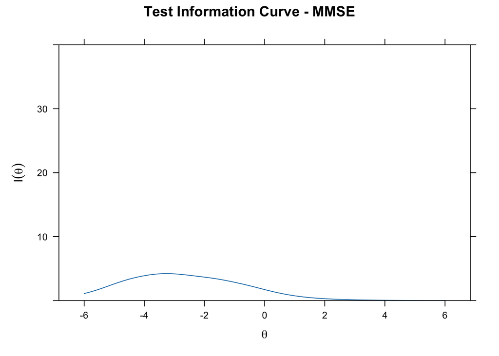

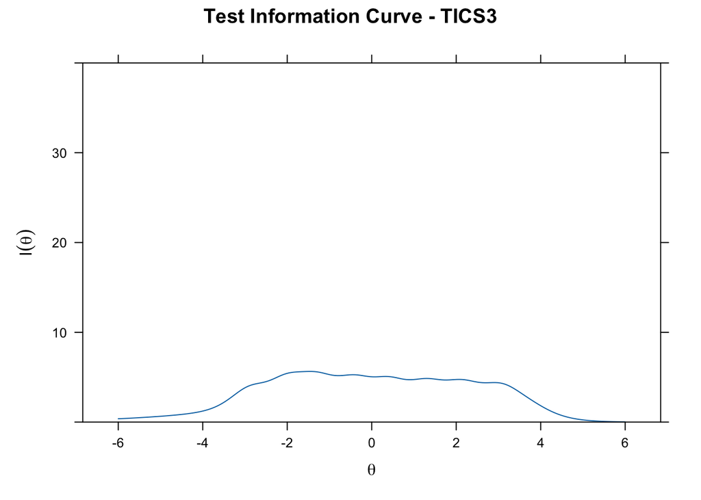

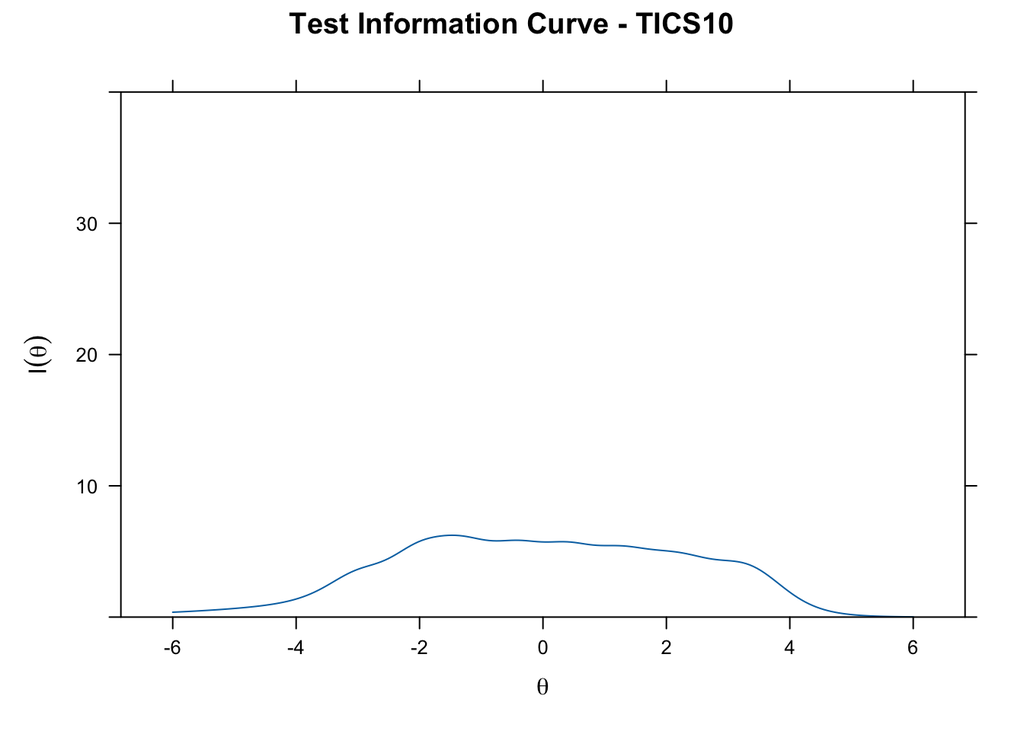

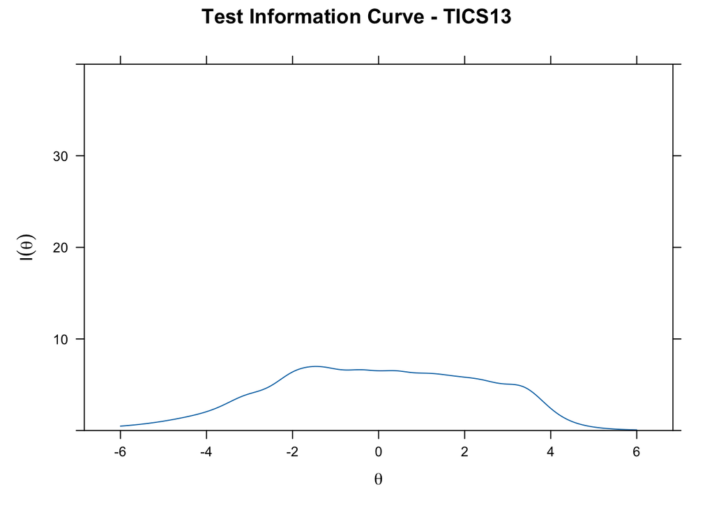

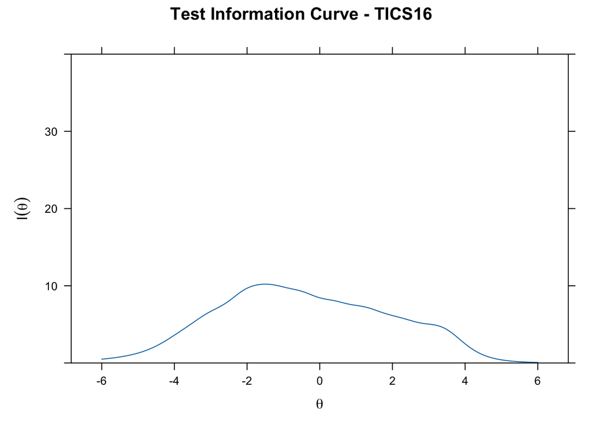

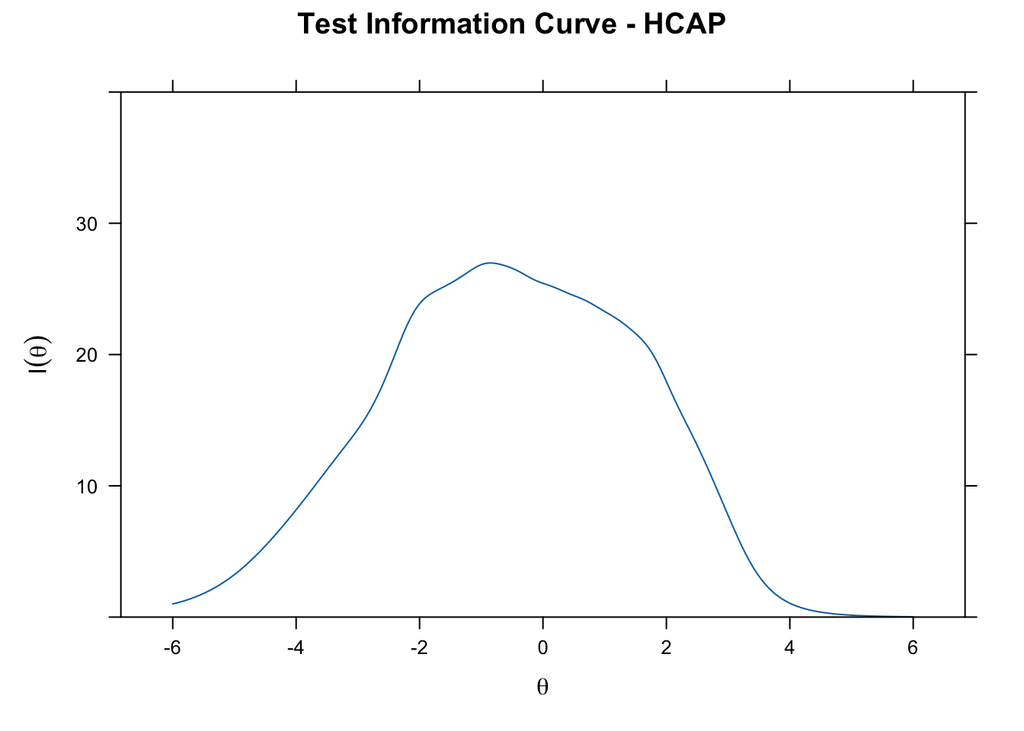

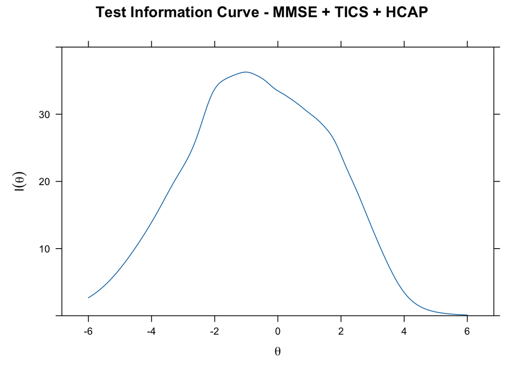

```r
extractMIRTParm <- function(model,max_thresh = 9) {
    require(mirt)

    parm <- mod2values(model)

    parmw <- parm %>% dplyr::select(item, name, value) %>%
        pivot_wider(id_cols = item, names_from = name, values_from = value) %>%
        filter(!item == "GROUP") %>% mutate(
            d1 = case_when(
                is.na(d1) ~ d,
                TRUE ~ d1
            )
        )

    a <- as.matrix(parmw %>% dplyr::select(a1))
    d <- as.matrix(parmw %>% dplyr::select(paste0("d",1:max_thresh)))
    return(list(a,d))
}

hcog <- readRDS("~/Psychometrics Conference/2024/Simulation WG/Data/hrs_hcap_co_calibration_analytic.rds")

### Item names for analysis

mmse_nmsr <- c("ornttime_mmser","orntplace_mmser","imrec_mmser","delrec_mmser",
               "spellbck_mmser","naming_mmser","phrase_mmser","commfoll_mmser","writesent_mmser",
               "draw_mmser","comm3step_mmser")

tics_nmsr <- c("wlimrc_ticsr","wldlrc_ticsr","cntbck_ticsr","animfl_ticsr",
               "numser_ticsr","serial7_ticsr","ornttime_ticsr","naming_ticsr")

hcap_nmsr <- c("naming_hcapr","ceradtot_hcapr","ceraddel_hcapr","ceradrcg_hcapr",
               "animfl_hcapr","bmim_hcapr","bmdel_hcapr","lmim_hcapr","lmdel_hcapr","lmrcg_hcapr",
               "conprxim_hcapr","conprxdel_hcapr","dsmt_hcapr","numser_hcapr","ravens_hcapr",
               "trailsa_hcapir","trailsb_hcapir","spatial_hcapr")

hcog1 <- hcog[,c(mmse_nmsr,tics_nmsr,hcap_nmsr)]

mirt_mmse <- "mmse = 1-11"
mirt_tics3 <- "tics = 1-6"
mirt_tics10 <- "tics = 1-7"
mirt_tics13 <- "tics = 1-8"
mirt_tics16 <- "tics = 1-10"
mirt_hcap <- "hcap = 1-18"
mirt_all <- "cog = 1-37"



true_sim <- readRDS("~/Psychometrics Conference/2024/Simulation WG/PsyMCA-2024-Simulation/Data/simulated_longitudinal_true_cognition.rds")

item_labels <- names(hcog1)

a <- extractMIRTParm((res_md_1a))[[1]]
d <- extractMIRTParm((res_md_1a))[[2]]

df <- data.frame(simdata(a = a, d = d, N = 1000, itemtype = 'graded'))

Theta <- matrix(seq(-6,6,.01))

# cat("Test Information Curve - MMSE")
mod <- mirt(data = df[,1:11], model = mirt_mmse)
info_mmse <- plot(mod, type = 'info', ylim = c(0,40),
     main = "Test Information Curve - MMSE")
# mmse_info <- testinfo(mod, Theta) %>% mutate(test = "MMSE")
mmse_info <- data.frame("Theta" = Theta,"info" = testinfo(mod, Theta)) %>%
    mutate(test = "MMSE")

# cat("Test Information Curve - TICS3")
mod <- mirt(data = df[,c(12:14,17:19)], model = mirt_tics3)
info_tics3 <- plot(mod, type = 'info', ylim = c(0,40),
     main = "Test Information Curve - TICS3")
# tics3_info <- testinfo(mod, Theta) %>% mutate(test = "TICS3")
tics3_info <- data.frame("Theta" = Theta,"info" = testinfo(mod, Theta)) %>%
    mutate(test = "TICS3")

# cat("Test Information Curve - TICS10")
mod <- mirt(data = df[,c(12:14,16:19)], model = mirt_tics10)
info_tics10 <- plot(mod, type = 'info', ylim = c(0,40),
     main = "Test Information Curve - TICS10")
# tics10_info <- testinfo(mod, Theta) %>% mutate(test = "TICS10")
tics10_info <- data.frame("Theta" = Theta,"info" = testinfo(mod, Theta)) %>%
    mutate(test = "TICS10")

# cat("Test Information Curve - TICS13")
mod <- mirt(data = df[,12:19], model = mirt_tics13)
info_tics13 <- plot(mod, type = 'info', ylim = c(0,40),
     main = "Test Information Curve - TICS13")
# tics13_info <- testinfo(mod, Theta) %>% mutate(test = "TICS13")
tics13_info <- data.frame("Theta" = Theta,"info" = testinfo(mod, Theta)) %>%
    mutate(test = "TICS13")

# cat("Test Information Curve - TICS16")
mod <- mirt(data = df[,c(12:19,35:36)], model = mirt_tics16)
info_tics16 <- plot(mod, type = 'info', ylim = c(0,40),
     main = "Test Information Curve - TICS16")
# tics16_info <- testinfo(mod, Theta) %>% mutate(test = "TICS16")
tics16_info <- data.frame("Theta" = Theta,"info" = testinfo(mod, Theta)) %>%
    mutate(test = "TICS16")

# cat("Test Information Curve - HCAP")
mod <- mirt(data = df[,20:37], model = mirt_hcap)
info_hcap <- plot(mod, type = 'info', ylim = c(0,40),
     main = "Test Information Curve - HCAP")
# hcap_info <- testinfo(mod, Theta) %>% mutate(test = "HCAP")
hcap_info <- data.frame("Theta" = Theta,"info" = testinfo(mod, Theta)) %>%
    mutate(test = "HCAP")

# # cat("Test Information Curve - HCAP")
# mod <- mirt(data = hcog[,hcap_nmsr], model = mirt_hcap)
# info_hcap <- plot(mod, type = 'info', ylim = c(0,40),
#      main = "Test Information Curve - HCAP")
# fit_hcap <- M2(mod,calcNull = TRUE, CI = 0.90, type = "C2", na.rm = TRUE,
#     QMC = TRUE)
#
# t2 <- data.frame(summary(res_md_1)$rotF)
# write.csv(t2,"../Analysis/Results/hrs_hcap_empirical_loadings_standardized.csv")
# coef(res_md_1)
# fit_md_1

# t2 <- read.csv("../Analysis/Results/hrs_hcap_empirical_loadings_standardized.csv")
# itnms <- t2$X
#
# t3 <- hcog[,itnms]
# describe(t3)
# psych::skew(t3)
# psych::kurtosi(t3)
#
# t2$skew <- psych::skew(t3)
# t2$kurtosis <- psych::kurtosi(t3)
# write.csv(t2,"../Analysis/Results/hrs_hcap_empirical_loadings_standardized.csv")
#
# t1 <- mod2values(res_md_1)
# rm(t1,t2,t3)

# cat("Test Information Curve - MMSE + TICS + HCAP")
mod <- mirt(data = df, model = mirt_all)
info_all <- plot(mod, type = 'info', ylim = c(0,40),
     main = "Test Information Curve - MMSE + TICS + HCAP")
# all_info <- testinfo(mod, Theta) %>% mutate(test = "MMSE+TICS+HCAP")
all_info <- data.frame("Theta" = Theta,"info" = testinfo(mod, Theta)) %>%
    mutate(test = "MMSE+TICS+HCAP")
```

## Simulation of Longitudinal Cognitive Change

### Simulation Functions

```r
require(lme4)
require(mirt)
require(tidyverse)
require(ggplot2)

# show size of environment objects
# sort( sapply(ls(),function(x){object.size(get(x))}))

# rm(list = ls()[grepl("^re",ls())])



#   extractMIRTParm is a function that extracts item parameters from a mirt
#       estimate multidimensional (uncorrelated dimensions) model and converts
#       discrimination (a) parameters to a vector of item parameters and
#       threshhold (d) parameters to a matrix of d values.
#   Parameters
#       model - estimated mirt model object
#       max_thresh - maximum number of threshold paramters across items
#   Value list with 2 elements
#       a - vector of a parameters, 1 for each item
#       d - matrix of d parameters, rows correspons to items, columns to threshholds

extractMIRTParm <- function(model,max_thresh = 9) {
    require(mirt)

    parm <- mod2values(model)

    parmw <- parm %>% dplyr::select(item, name, value) %>%
        pivot_wider(id_cols = item, names_from = name, values_from = value) %>%
        filter(!item == "GROUP") %>% mutate(
            d1 = case_when(
                is.na(d1) ~ d,
                TRUE ~ d1
            )
        )

    a <- as.matrix(parmw %>% dplyr::select(a1))
    d <- as.matrix(parmw %>% dplyr::select(paste0("d",1:max_thresh)))
    return(list(a,d))
}


#   simTraj is a function that 1) estimates a mirt model using a simulated
#       item response dataset, 2) calculates factor scores based on the estimated
#       model, 3) estimates linear mixed effects models with true cognition and
#       simulated cognition (factor scores from simulated item responses) as dependent
#       variables, time in study as a fixed effect variable, and person and
#       person-by-time random effects, and 4) returns person specific estimates
#       (random effects) of cognitive components slopes and intercepts.
#   Parameters
#       data - data frame that contains true cognition value, simulated item responses,
#           id variable, and time in study variable
#       sim_cog_var - label for variable within dataframe (data) for which
#           trajectories are being simulated
#       frml - formula specification for (lmer) longitudinal mixed effects model
#       iteration = iteration number passed from simulateTrajectories
#   Value - list with 3 elements:
#       data - analytic dataframe (data) with longitudinal model predicted cognition
#           values for each assessment
#       re - data frame with estimated random effects from longitudinal model.
#           Includes intercept and slope random effects for true cognition (_true)
#           and simulated cognition factor scores (_sim)
#       fe - data frame with estimated fixed effects from longitudinal model.

# simTraj <- function(data = df, item_labels = item_labels, mirt_mod = mirt_all,
#     iteration = iteration) {
simTraj <- function(data = df, sim_cog_var = "sim_cog_all", frml = frml,
    iteration = iteration) {
    require(tidyverse)
    require(lme4)

    # # estimate mirt model using simulated responses and generate factor scores
    re_empty <- data.frame(id = NA, int_true = NA, slope_true = NA,
        int_true_se = NA,slope_true_se = NA, int_sim = NA, slope_sim = NA,
        int_sim_se = NA, slope_sim_se = NA)
    #
    # tryCatch({
    #     mod <- mirt(data[,item_labels], mirt_mod)
    #     data$sim_cog <- fscores(mod)
    #     data <- data %>% relocate(sim_cog, .after = true_cog)
    # }, error=function(e){return(re_empty)})
    # data$itertion <- iteration

    # frml <- "true_cog ~ time + agebl_75 + slope_true_qrtl +
    # time:agebl_75 + time:slope_true_qrtl + (1 + time | id)"
    # frml <- "true_cog ~ time + agebl_75 +
    # time:agebl_75 + (1 | id)"
    #
    tryCatch({
        # mixed effects longitudinal model - true cognition
        # res_long_true <- lmer(true_cog ~ time + (1 + time | id), data = data)
        res_long_true <- lmer(formula = frml, data = data)
        # summary(res_long_true)
        # str(coef(res_long_true))
        data$cog_true_pred <- predict(res_long_true, newdata = data, type = "response")
        re_true <- data.frame(ranef(res_long_true))
        re_true <- re_true %>%
            pivot_wider(id_cols = grp, names_from = term,values_from = c(condval,condsd))
        names(re_true) <- c("id","int_true","slope_true","int_true_se","slope_true_se")
        re_true$id <- as.integer(levels(re_true$id))[re_true$id]
        fe_true <- data.frame(t(lme4::fixef(res_long_true)))
        names(fe_true) <- paste0(names(fe_true),"_true")


        data$sim_cog <- data[,sim_cog_var]
        #res_long_sim <- lmer(sim_cog ~ time + (1 + time | id), data = data)
        frml <- sub("true_cog","sim_cog",frml)
        res_long_sim <- lmer(formula = frml, data = data)
        # summary(res_long_sim)

        data$cog_sim_pred <- predict(res_long_sim, newdata = data, type = "response")
        data <- data %>% dplyr::select(-sim_cog)
        re_sim <- data.frame(ranef(res_long_sim))
        re_sim <- re_sim %>%
            pivot_wider(id_cols = grp, names_from = term,values_from = c(condval,condsd))
        names(re_sim) <- c("id","int_sim","slope_sim","int_sim_se","slope_sim_se")
        re_sim$id <- as.integer(levels(re_sim$id))[re_sim$id]
        fe_sim <- data.frame(t(lme4::fixef(res_long_sim)))
        names(fe_sim) <- paste0(names(fe_sim),"_sim")

        re <- re_true %>% left_join(re_sim, by="id")
        fe <- bind_cols(fe_true,fe_sim)
        fe$iteration <- iteration

    }, error=function(e){re <- re_empty})
    re$iteration <- iteration

    return(list(data,re,fe))

}

#   simulateTrajectories is a function that 1) simulates item responses for
#   true cognition vectors for different measures derived from the HRS-HCAP cognitive test
#   battery (MMSE, HRS TICS, HCAP, MMSE+TICS+HCAP), 2) generates simulated observed (factor)
#   scores for each of the cognitive measures, 3) estimates linear mixed effects models
#   with true cognition and simulated cognition (factor scores from simulated item responses)
#   as dependent variables, time in study as a fixed effect variable, and person and
#   person-by-time random effects (simTraj()), 4) collates and outputs simulated datasets
#   that include simulated item level responses and factor scores, random effects,
#   and fixed effects from mixed effects models.
#   Up to 10 cognitive measures can be processed in each run.
#
#   Parameters
#       iter_group - number of groups of (niter) iterations
#       niter - number of simulation iterations within iteration groups
#       item_labels - vector that contains variable names of superset of items that occur
#           in any of the simulated measures (union of items across simulated measures)
#       * vectors with mirt design parameters (must have the same number of elements)
#       models - vector, each element contains mirt model syntax for one simulated measure
#           e.g. "dv1 = 1:5"
#       dv_labels - vector, each element contains factor label for one simulated measure
#           e.g. "dv1"
#       items - vector, each element is a vector that contains item numbers
#           (corresponding to item_labels) for one simulated measure
#           e.g. "c(1:3,4,7)"
#       in_dir - path to directory for input of previously generated simulated
#           item response datasets. if is.null(in_dir) item responses will be simulated
#           using true_sim, a_par, and d_par
#       * required if is.null(in_dir):
#           true_sim - data frame with true cognition values, rows correspond to assessments,
#               columns correspond to simulation iterations.
#           a_par - vector/data frame containing a (discrimination) item parameters
#               from mirt co-calibration model
#           d_par - vector/data frame containing d (threshhold) item parameters
#               from mirt co-calibration model
#       out_dir - path to directory for output of simulation results
#       frml - formula specification for (lmer) longitudinal mixed effects model
#           e.g. "true_cog ~ time + (1 + time | id)"
#
#   Value - Saves lists of results to out_dir - there is a file for each iter_group
#       that contains a list with niter elements. There are also files that merge
#       random effects and fixed effects across iterations. These files contain granular
#       results from the simulations and can be individually and cumulatively large.
#
#       ds_iteration_group_<iter_group number> - list of datasets for each of the
#           niter simulations. Each dataset contains the true cognition value (true_cog),
#           the simulated item responses conditional on true_cog, cognition factor scores,
#           and longitudinal mixed effect model predicted cognition values for each simulated
#           measure specified in dv_labels. Can be large.
#       re_<dv>_iteration_group_<iter_group number> - list of estimated random effects
#           for each of the niter simulations  for each simulated measure specified
#           in dv_labels. Includes intercept and slope random effects for
#           cognition (_true) and simulated cognition factor scores (_sim)
#       fe_<dv>_iteration_group_<iter_group number> - list of estimated fixed effects
#           for each of the niter simulations for each simulated measure specified in dv_labels.
#       re_<dv> - dataframe that contains random effects from all of the iterations
#           (iter_group * niter) for specified simulated measure (dv).
#           Includes intercept and slope random effects for
#           cognition (_true) and simulated cognition factor scores (_sim).
#           Can be large.
#       fe_<dv> - dataframe that contains fixed effects from all of the iterations
#           (iter_group * niter) for specified simulated measure (dv).
```

```r
simulateTrajectories <- function(iter_group = 5, niter = 20, item_labels,
                    true_sim, a_par, d_par,
                    models, dv_labels, items,
                    in_dir = NULL,
                    out_dir = "Analysis/Simulation Results/",
                    frml = "true_cog ~ time + (1 | id)") {
    require(mirt)
    require(tidyverse)

    # design <- data.frame(dv_labels,models,items)
    varnms <- paste0("sim_cog_",dv_labels)
    varnms_rs <- paste0(varnms,"_rs")
    for (itgrp in 1:iter_group) {
        ds <- list()
        for (i in 1:length(dv_labels)) {
            assign(paste0("re_",i),list())
            assign(paste0("fe_",i),list())
        }

        set.seed(092724)
        for (iter in 1:niter) {
            cat(paste0("Group - ",itgrp, ", Iteration - ",iter,"\n"))

            # simulate item responses
            iteration <- ((itgrp - 1) * niter) + iter

            if (is.null(in_dir)){
                df <- data.frame(simdata(a = a_par, d = d_par, Theta = true_sim[,paste0("vm",iteration)],
                    itemtype = 'graded'))
                names(df) <- item_labels
                df$id <- true_sim$id
                df$time <- true_sim$time
                df$agebl_75 <- true_sim$agebl_75
                df$true_cog <- true_sim[,paste0("vm",iteration)]
                df$iteration <- iteration
                df <- df %>% relocate(c(id,iteration,time,true_cog))

                # true random effect intercept and slope - from calculate_re_true.R
                # In Dropbox/PsyMCA2024_Sharing/WG4_Simulation/Longitudinal_Cognition_Simulation/Observed Cognition Longitudinal Simulation/Data/
                true_re <- readRDS("~/Psychometrics Conference/2024/Simulation WG/PsyMCA-2024-Simulation/Data/true_random_effects.rds")
                df <- df %>% left_join((true_re %>% dplyr::select(id,int_true_qrtl,
                        slope_true_qrtl)),by="id")

                flag_low_response <- FALSE
                for (itnm in item_labels) {
                    if (length(table(df[,itnm])) < 2) {
                        flag_low_response <- TRUE
                    }
                }
                if (flag_low_response == TRUE) {
                    iter = iter - 1
                    next
                }
            } else {
                df <- readRDS(paste0(in_dir,"ds_iteration_group_",itgrp,".rds"))[[iter]]
                df <- df %>% dplyr::select(c(id:true_cog,agebl_75:slope_true_qrtl,any_of(item_labels)))
            }

            for (i in 1:length(dv_labels)) {
                assign(paste0("mirt_dv",i),models[i])
            }

            ### estimate mirt model using simulated responses and generate factor scores
            # create empty re dataframe to return if error in generation
            re_empty <- data.frame(id = NA, int_true = NA, slope_true = NA,
                                   int_true_se = NA,slope_true_se = NA, int_sim = NA, slope_sim = NA,
                                   int_sim_se = NA, slope_sim_se = NA)

            tryCatch({

                for (i in 1:length(dv_labels)) {
                    itms <- eval(parse(text = items[i]))
                    mod <- mirt(df[,item_labels[itms]], models[i])
                    df[,paste0("sim_cog_",dv_labels[i])] <- fscores(mod)
                }
                # varnms <- paste0("sim_cog_",dv_labels)
                df <- df %>%
                    relocate(all_of(varnms),
                             .after = true_cog)
            }, error=function(e){return(re_empty)})

            # rescale factor scores to equate metric to true cognition

            # varnms_rs <- paste0(varnms,"_rs")

            for (i in 1:length(dv_labels)) {
                df[,varnms_rs[i]] <-
                    (((df[,varnms[i]] - mean(df[,varnms[i]])) /
                          sd(df[,varnms[i]])) * sd(df$true_cog)) + mean(df$true_cog)
            }

            # mixed effects model of simulated longitudinal data
            for (i in 1:length(dv_labels)) {
                res <- simTraj(data = df, sim_cog_var = varnms_rs[i],frml = frml,
                    iteration = iteration)

                df <- res[[1]]
                names(df) <- sub("cog_true_pred$",paste0("cog_true_pred_",
                    dv_labels[i]),names(df))
                names(df) <- sub("cog_sim_pred$",paste0("cog_sim_pred_",
                    dv_labels[i]),names(df))

                re <- res[[2]]
                re$label <- toupper(dv_labels[i])

                fe <- res[[3]]
                fe$label <- toupper(dv_labels[i])

                if (i == 1) {
                    re_1[[paste0("iteration-",iteration)]] = re
                    fe_1[[paste0("iteration-",iteration)]] = fe
                }
                if (i == 2) {
                    re_2[[paste0("iteration-",iteration)]] = re
                    fe_2[[paste0("iteration-",iteration)]] = fe
                }
                if (i == 3) {
                    re_3[[paste0("iteration-",iteration)]] = re
                    fe_3[[paste0("iteration-",iteration)]] = fe
                }
                if (i == 4) {
                    re_4[[paste0("iteration-",iteration)]] = re
                    fe_4[[paste0("iteration-",iteration)]] = fe
                }
                if (i == 5) {
                    re_5[[paste0("iteration-",iteration)]] = re
                    fe_5[[paste0("iteration-",iteration)]] = fe
                }
                if (i == 6) {
                    re_6[[paste0("iteration-",iteration)]] = re
                    fe_6[[paste0("iteration-",iteration)]] = fe
                }
                if (i == 7) {
                    re_7[[paste0("iteration-",iteration)]] = re
                    fe_7[[paste0("iteration-",iteration)]] = fe
                }
                if (i == 8) {
                    re_8[[paste0("iteration-",iteration)]] = re
                    fe_8[[paste0("iteration-",iteration)]] = fe
                }
                if (i == 9) {
                    re_9[[paste0("iteration-",iteration)]] = re
                    fe_9[[paste0("iteration-",iteration)]] = fe
                }
                if (i == 10) {
                    re_10[[paste0("iteration-",iteration)]] = re
                    fe_10[[paste0("iteration-",iteration)]] = fe
                }
            }
```

```r
            ds[[paste0("iteration-",iteration)]] <- df


        } # end for iter

        saveRDS(ds, file = paste0(out_dir,"ds_iteration_group_", itgrp, ".rds"))

        for (i in 1:length(dv_labels)) {
            saveRDS(eval(parse(text=paste0("re_",i))),
                    file = paste0(out_dir,"re_",dv_labels[i],
                                  "_iteration_group_", itgrp, ".rds"))
            saveRDS(eval(parse(text=paste0("fe_",i))),
                    file = paste0(out_dir,"fe_",dv_labels[i],
                                  "_iteration_group_", itgrp, ".rds"))
        }

    } # end for itgrp

    for (itgrp in 1:iter_group) {
        if (itgrp == 1) {
            for (i in 1:length(dv_labels)) {
                assign(paste0("re_",i),
                       readRDS(paste0(out_dir,"re_",dv_labels[i],
                                      "_iteration_group_", itgrp, ".rds")) %>% bind_rows())
                assign(paste0("fe_",i),
                       readRDS(paste0(out_dir,"fe_",dv_labels[i],
                                      "_iteration_group_", itgrp, ".rds")) %>% bind_rows())
            }

        } else {
            for (i in 1:length(dv_labels)) {
                re_temp <- readRDS(paste0(out_dir,"re_",dv_labels[i],
                                          "_iteration_group_", itgrp, ".rds")) %>% bind_rows()
                assign(paste0("re_",i),
                       eval(parse(text=paste0("re_",i))) %>% bind_rows(re_temp))
                fe_temp <- readRDS(paste0(out_dir,"fe_",dv_labels[i],
                                          "_iteration_group_", itgrp, ".rds")) %>% bind_rows()
                assign(paste0("fe_",i),
                       eval(parse(text=paste0("fe_",i))) %>% bind_rows(fe_temp))
            }

        }
    }
    for (i in 1:length(dv_labels)) {
        saveRDS(eval(parse(text=paste0("re_",i))),
                file = paste0(out_dir,"re_",dv_labels[i],".rds"))
        saveRDS(eval(parse(text=paste0("fe_",i))),
                file = paste0(out_dir,"fe_",dv_labels[i],".rds"))
    }

}

#   simulateBlendedTrajectories is a function that inputs previously generated cognitive
#       test scores, "blends" results from two measures into a new variable
#       (the first measure will comprise the baseline assessment through blend_time,
#       the second will include assessments subsequent to blend_time). It estimates
#       linear mixed effect (lmer) models via simTraj() and outputs results that are
#       comparable to those from simulateTrajectories().
#   Up to 10 cognitive measures can be processed in each run.
#
#   Parameters
#       iter_group - number of groups of (niter) iterations
#       niter - number of simulation iterations within iteration groups
#       blend_labels - vector that contains label for measures that will be blended.
#           each element is a vector with two elements that are labels for the
#           first and second measures to be blended (e.g. "tics3-tics13"). A simple,
#           non-blended measure can be specified by repeating the measure
#           (e.g. "tics3-tics3").
#       blend_time - time-in-study cut-point for assigning first or second measure
#           to blended measure. First is assigned to assessments with time ≤ blend_time,
#           second to time > blend_time.
#       in_dir - path to directory for input of previously generated simulated
#           item response datasets. if is.null(in_dir) item responses will be simulated
#           using true_sim, a_par, and d_par
#       out_dir - path to directory for output of simulation results
#       frml - formula specification for (lmer) longitudinal mixed effects model
#           e.g. "true_cog ~ time + (1 + time | id)"
#
#   Value - Saves lists of results to out_dir - there is a file for each iter_group
#       that contains a list with niter elements. There are also files that merge
#       random effects and fixed effects across iterations. These files contain granular
#       results from the simulations and can be individually and cumulatively large.
#
#       ds_iteration_group_<iter_group number> - list of datasets for each of the
#           niter simulations. Each dataset contains the true cognition value (true_cog),
#           the simulated item responses conditional on true_cog, cognition factor scores,
#           and longitudinal mixed effect model predicted cognition values for each simulated
#           measure specified in dv_labels. Can be large.
#       re_<dv>_iteration_group_<iter_group number> - list of estimated random effects
#           for each of the niter simulations  for each simulated measure specified
#           in dv_labels. Includes intercept and slope random effects for
#           cognition (_true) and simulated cognition factor scores (_sim)
#       fe_<dv>_iteration_group_<iter_group number> - list of estimated fixed effects
#           for each of the niter simulations for each simulated measure specified in dv_labels.
#       re_<dv> - dataframe that contains random effects from all of the iterations
#           (iter_group * niter) for specified simulated measure (dv).
#           Includes intercept and slope random effects for
#           cognition (_true) and simulated cognition factor scores (_sim).
#           Can be large.
#       fe_<dv> - dataframe that contains fixed effects from all of the iterations
#           (iter_group * niter) for specified simulated measure (dv).




simulateBlendedTrajectories <- function(niter = 20, iter_group = 5,
                    blend_labels = blend_labels,
                    blend_time = blend_time,
                    in_dir = "Analysis/Simulation Results/",
                    out_dir = "Analysis/Simulation Results/",
                    frml = "true_cog ~ time + (1 | id)") {
    require(mirt)
    require(tidyverse)
    require(stringr)
    # source("~/Psychometrics Conference/2024/Simulation WG/PsyMCA-2024-Simulation/Code/simulate_trajectories.R")
```

```r
    dv_labels <- blend_labels
    design <- data.frame(dv_labels)
    design <- design %>% mutate(
        dv1 = str_extract(dv_labels,"^.*(?=-)"),
        dv2 = str_extract(dv_labels,"(?<=-).*")
    )

    for (itgrp in 1:iter_group) {
        ds <- list()
        for (i in 1:length(design$dv_labels)) {
            assign(paste0("re_",i),list())
            assign(paste0("fe_",i),list())
        }
        set.seed(092724)
        for (iter in 1:niter) {
            cat(paste0("Group - ",itgrp, ", Iteration - ",iter,"\n"))

            #  load simulated item responses
            iteration <- ((itgrp - 1) * niter) + iter
            df <- readRDS(paste0(in_dir,"ds_iteration_group_",itgrp,".rds"))[[iter]]
            df <- df %>% dplyr::select(c(id:true_cog,agebl_75:slope_true_qrtl,any_of(item_labels),
                                         ends_with("_rs")))

            for (i in 1:length(design$dv_labels)) {
                lbl <- paste0("sim_cog_",design$dv_labels[i],"_rs")
                lbl1 <- paste0("sim_cog_",design$dv1[i],"_rs")
                lbl2 <- paste0("sim_cog_",design$dv2[i],"_rs")
                df[,lbl] <- case_when(
                    df$time <= blend_time ~ df[,lbl1],
                    df$time > blend_time ~ df[,lbl2]
                )

            }


            # mixed effects model of simulated longitudinal data

            varnms_rs <- paste0("sim_cog_",design$dv_labels,"_rs")

            for (i in 1:length(design$dv_labels)) {
                res <- simTraj(data = df, sim_cog_var = varnms_rs[i],frml = frml,
                               iteration = iteration)

                df <- res[[1]]
                names(df) <- sub("cog_true_pred$",paste0("cog_true_pred_",
                                                         design$dv_labels[i]),names(df))
                names(df) <- sub("cog_sim_pred$",paste0("cog_sim_pred_",
                                                        design$dv_labels[i]),names(df))

                re <- res[[2]]
                re$label <- toupper(design$dv_labels[i])

                fe <- res[[3]]
                fe$label <- toupper(design$dv_labels[i])

                if (i == 1) {
                    re_1[[paste0("iteration-",iteration)]] = re
                    fe_1[[paste0("iteration-",iteration)]] = fe
                }
                if (i == 2) {
                    re_2[[paste0("iteration-",iteration)]] = re
                    fe_2[[paste0("iteration-",iteration)]] = fe
                }
                if (i == 3) {
                    re_3[[paste0("iteration-",iteration)]] = re
                    fe_3[[paste0("iteration-",iteration)]] = fe
                }
                if (i == 4) {
                    re_4[[paste0("iteration-",iteration)]] = re
                    fe_4[[paste0("iteration-",iteration)]] = fe
                }
                if (i == 5) {
                    re_5[[paste0("iteration-",iteration)]] = re
                    fe_5[[paste0("iteration-",iteration)]] = fe
                }
                if (i == 6) {
                    re_6[[paste0("iteration-",iteration)]] = re
                    fe_6[[paste0("iteration-",iteration)]] = fe
                }
                if (i == 7) {
                    re_7[[paste0("iteration-",iteration)]] = re
                    fe_7[[paste0("iteration-",iteration)]] = fe
                }
                if (i == 8) {
                    re_8[[paste0("iteration-",iteration)]] = re
                    fe_8[[paste0("iteration-",iteration)]] = fe
                }
                if (i == 9) {
                    re_9[[paste0("iteration-",iteration)]] = re
                    fe_9[[paste0("iteration-",iteration)]] = fe
                }
                if (i == 10) {
                    re_10[[paste0("iteration-",iteration)]] = re
                    fe_10[[paste0("iteration-",iteration)]] = fe
                }
            }

            ds[[paste0("iteration-",iteration)]] <- df


        } # end for iter

        saveRDS(ds, file = paste0(out_dir,"ds_iteration_group_", itgrp, ".rds"))

        for (i in 1:length(design$dv_labels)) {
            saveRDS(eval(parse(text=paste0("re_",i))),
                    file = paste0(out_dir,"re_",design$dv_labels[i],
                                  "_iteration_group_", itgrp, ".rds"))
            saveRDS(eval(parse(text=paste0("fe_",i))),
                    file = paste0(out_dir,"fe_",design$dv_labels[i],
                                  "_iteration_group_", itgrp, ".rds"))
        }

    } # end for itgrp

    for (itgrp in 1:iter_group) {
        if (itgrp == 1) {
            for (i in 1:length(design$dv_labels)) {
                assign(paste0("re_",i),
                       readRDS(paste0(out_dir,"re_",design$dv_labels[i],
                                      "_iteration_group_", itgrp, ".rds")) %>% bind_rows())
                assign(paste0("fe_",i),
                       readRDS(paste0(out_dir,"fe_",design$dv_labels[i],
                                      "_iteration_group_", itgrp, ".rds")) %>% bind_rows())
            }


        } else {
            for (i in 1:length(design$dv_labels)) {
                re_temp <- readRDS(paste0(out_dir,"re_",design$dv_labels[i],
                                          "_iteration_group_", itgrp, ".rds")) %>% bind_rows()
                assign(paste0("re_",i),
                       eval(parse(text=paste0("re_",i))) %>% bind_rows(re_temp))
                fe_temp <- readRDS(paste0(out_dir,"fe_",design$dv_labels[i],
                                          "_iteration_group_", itgrp, ".rds")) %>% bind_rows()
                assign(paste0("fe_",i),
                       eval(parse(text=paste0("fe_",i))) %>% bind_rows(fe_temp))
            }



        }
    }

    for (i in 1:length(design$dv_labels)) {
        saveRDS(eval(parse(text=paste0("re_",i))),
                file = paste0(out_dir,"re_",design$dv_labels[i],".rds"))
        saveRDS(eval(parse(text=paste0("fe_",i))),
                file = paste0(out_dir,"fe_",design$dv_labels[i],".rds"))
    }
```

```r
}


# dat_cols <- c("id","time","age","agebl_75","slope_true_qrtl","int_true_qrtl")
# res_cols <- c("cog_true_pred_all","cog_sim_pred_all","cog_sim_pred_mmse",
#               "cog_sim_pred_tics","cog_sim_pred_hcap")

mergeSimResults <-function(file_name = "ds_iteration_group_1.rds",
                           out_dir = out_dir,
                           dat_cols = dat_cols,
                           res_cols = res_cols,
                           iter_group = 50,
                           niter = 20) {
    res <- (readRDS(paste0(out_dir,file_name))[[1]] %>%
                dplyr::select(any_of(dat_cols)))
    for (i in 1:iter_group) {
        for (n in 1:niter) {
            iteration <- ((i-1) * niter) + n
            fl_nm <- sub("_1",paste0("_",i),file_name)
            ds <- readRDS(paste0(out_dir,fl_nm))[[n]] %>%
                dplyr::select(all_of(res_cols))
            names(ds) <- paste0(res_cols,".",iteration)
            res <- res %>% bind_cols(ds)
        }
    }
        return(res)
}
```

### Simulated Cognition Change versus True Cognition Change Plots

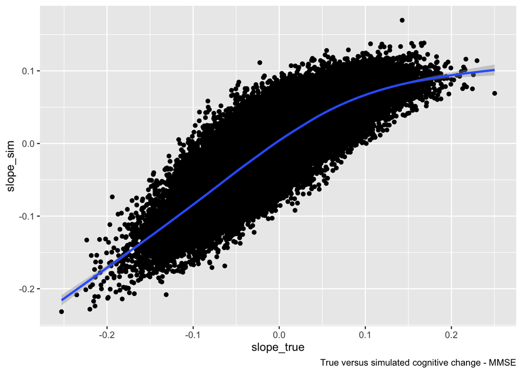

```r
# sim20 <- readRDS("~/Psychometrics Conference/2024/Simulation WG/PsyMCA-2024-Simulation/Analysis/sim20.rds")
#
# re_all <- sim20[["re_all"]]
# re_mmse <- sim20[["re_mmse"]]
# re_tics <- sim20[["re_tics"]]
# re_hcap <- sim20[["re_hcap"]]

out_dir <- "~/Psychometrics Conference/2024/Simulation WG/PsyMCA-2024-Simulation/Analysis/Simulation Results/10_04_24_unconditional/"

re_all <- readRDS(paste0(out_dir,"re_all.rds"))
re_mmse <- readRDS(paste0(out_dir,"re_mmse.rds"))
re_tics <- readRDS(paste0(out_dir,"re_tics.rds"))
re_hcap <- readRDS(paste0(out_dir,"re_hcap.rds"))

re_all_summ <- bind_rows(re_all)
re_mmse_summ <- bind_rows(re_mmse)
re_tics_summ <- bind_rows(re_tics)
re_hcap_summ <- bind_rows(re_hcap)

ggplot(data=re_mmse,aes(slope_true,slope_sim)) +
    geom_point() +
    geom_smooth() +
    labs(caption = "True versus simulated cognitive change - MMSE")
```

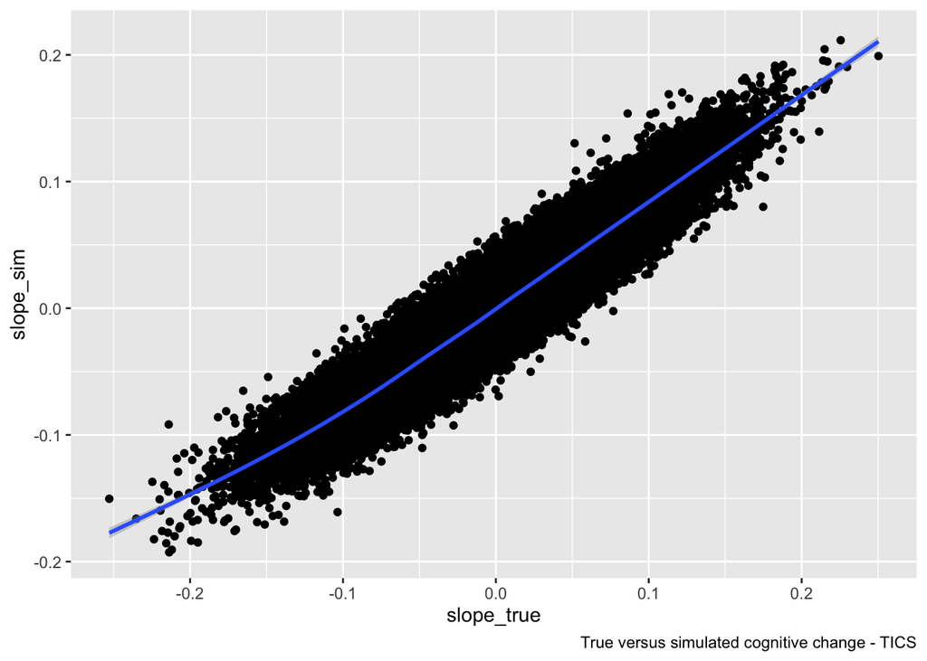

```r
ggplot(data=re_tics,aes(slope_true,slope_sim)) +
    geom_point() +
    geom_smooth() +
    labs(caption = "True versus simulated cognitive change - TICS")
```

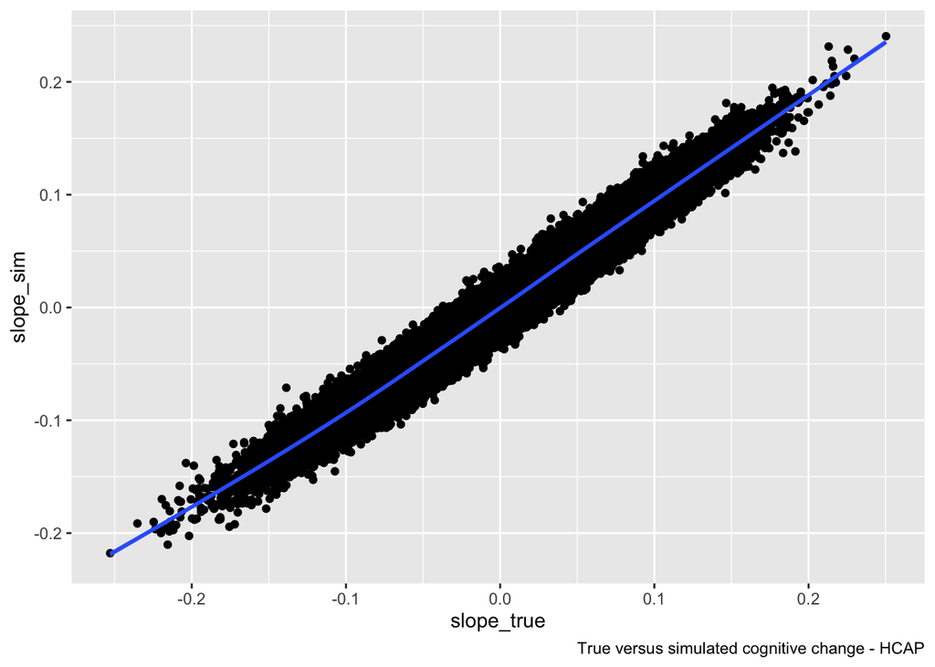

```r
ggplot(data=re_hcap,aes(slope_true,slope_sim)) +
    geom_point() +
    geom_smooth() +
    labs(caption = "True versus simulated cognitive change - HCAP")
```

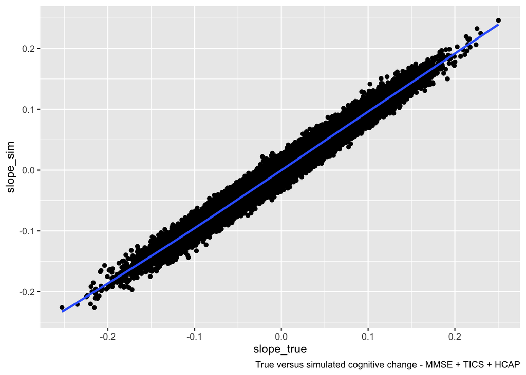

```r
ggplot(data=re_all,aes(slope_true,slope_sim)) +
    geom_point() +
    geom_smooth() +
    labs(caption = "True versus simulated cognitive change - MMSE + TICS + HCAP")
```

### Simulated Cognitive Trajectories versus True Cognition Trajectories

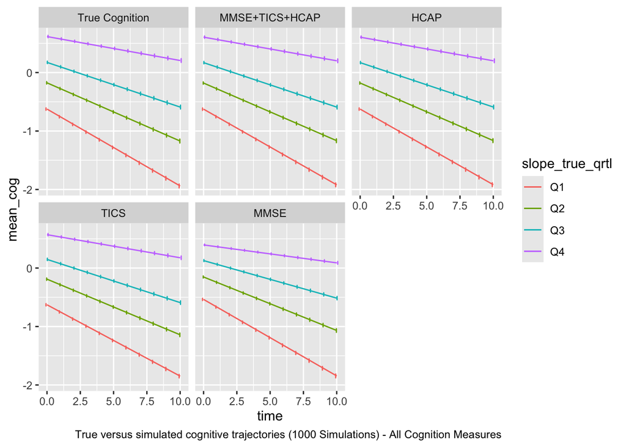

```r
# Create model predicted trajectories

# # code to create merged r1 dataset
# dat_cols <- c("id","time","agebl_75","slope_true_qrtl","int_true_qrtl")
# res_cols <- c("cog_true_pred_all","cog_sim_pred_all","cog_sim_pred_mmse",
#               "cog_sim_pred_tics","cog_sim_pred_hcap")
# out_dir <- "Analysis/Simulation Results/"
#
# r1 <- mergeSimResults(file_name = "ds_iteration_group_1.rds", out_dir = out_dir,
#                       dat_cols = dat_cols, res_cols = res_cols, iter_group = 50, niter = 20)
# saveRDS(r1,file=paste0(out_dir,"model_predicted_trajectory_simulations.rds"))
#
# rm(r1)


# prepare longitudinal data file

out_dir <- "~/Psychometrics Conference/2024/Simulation WG/PsyMCA-2024-Simulation/Analysis/Simulation Results/10_15_24/"
dat_cols <- c("id","time","agebl_75","slope_true_qrtl","int_true_qrtl")
res_cols <- c("cog_true_pred_all","cog_sim_pred_all","cog_sim_pred_mmse",
              "cog_sim_pred_tics","cog_sim_pred_hcap")


r1 <- readRDS(paste0(out_dir,"model_predicted_trajectory_simulations.rds"))

r1$cog_true_pred_mn <- apply(r1[,names(r1)[grepl("cog_true", names(r1))]], 1,
    function(x) mean(x, na.rm = TRUE))
r1$cog_true_pred_se <- apply(r1[,names(r1)[grepl("cog_true", names(r1))]], 1,
    function(x) sd(x, na.rm = TRUE))
# summary(r1$cog_true_mn)
r1$cog_sim_pred_all_mn <- apply(r1[,names(r1)[grepl("sim_pred_all", names(r1))]], 1,
    function(x) mean(x, na.rm = TRUE))
r1$cog_sim_pred_all_se <- apply(r1[,names(r1)[grepl("sim_pred_all", names(r1))]], 1,
    function(x) sd(x, na.rm = TRUE))

r1$cog_sim_pred_mmse_mn <- apply(r1[,names(r1)[grepl("sim_pred_mmse", names(r1))]], 1,
    function(x) mean(x, na.rm = TRUE))
r1$cog_sim_pred_mmse_se <- apply(r1[,names(r1)[grepl("sim_pred_mmse", names(r1))]], 1,
    function(x) sd(x, na.rm = TRUE))

r1$cog_sim_pred_tics_mn <- apply(r1[,names(r1)[grepl("sim_pred_tics", names(r1))]], 1,
    function(x) mean(x, na.rm = TRUE))
r1$cog_sim_pred_tics_se <- apply(r1[,names(r1)[grepl("sim_pred_tics", names(r1))]], 1,
    function(x) sd(x, na.rm = TRUE))

r1$cog_sim_pred_hcap_mn <- apply(r1[,names(r1)[grepl("sim_pred_all", names(r1))]], 1,
    function(x) mean(x, na.rm = TRUE))
r1$cog_sim_pred_hcap_se <- apply(r1[,names(r1)[grepl("sim_pred_all", names(r1))]], 1,
    function(x) sd(x, na.rm = TRUE))

r2 <- r1 %>% dplyr::select(any_of(dat_cols),contains("_mn"),contains("_se")) %>%
    mutate(age = agebl_75 + 75)
# summary(r2$age)

r3a <- r2 %>% dplyr::select(-c(cog_true_pred_se:cog_sim_pred_hcap_se)) %>%
    pivot_longer(cols = cog_true_pred_mn:cog_sim_pred_hcap_mn,
        names_to = "label", values_to = "cog") %>% mutate(
          label = sub("_mn$","",label)
        )
r3b <- r2 %>% dplyr::select(-c(cog_true_pred_mn:cog_sim_pred_hcap_mn)) %>%
    pivot_longer(cols = cog_true_pred_se:cog_sim_pred_hcap_se,
        names_to = "label", values_to = "cog_se") %>% mutate(
          label = sub("_se$","",label)
        )

r3 <- r3a %>% left_join((r3b %>%
    dplyr::select(id,time,label,cog_se)),by=c("id","time","label")) %>%
    mutate(
        cognitive_measure = factor(case_when(
            label == "cog_true_pred" ~ "True Cognition",
            label == "cog_sim_pred_all" ~ "MMSE+TICS+HCAP",
            label == "cog_sim_pred_mmse" ~ "MMSE",
            label == "cog_sim_pred_tics" ~ "TICS",
            label == "cog_sim_pred_hcap" ~ "HCAP",
        ), levels = c("True Cognition","MMSE+TICS+HCAP","HCAP","TICS","MMSE"))
    )

r4 <- r3 %>% group_by(time,slope_true_qrtl,cognitive_measure) %>% summarise(
    mean_cog = mean(cog),
    se_cog = mean(cog_se) / sqrt(1000)
) %>% mutate(
    lower = mean_cog - (1.96 * se_cog),
    upper = mean_cog + (1.96 * se_cog),
)

r2ta <- r2 %>% dplyr::select(id,time,agebl_75,slope_true_qrtl,
    cog_sim_pred_tics_mn,cog_sim_pred_all_mn,cog_sim_pred_tics_se,cog_sim_pred_all_se) %>%
      mutate(
        cog_blend_mn = case_when(
          time <= 5 ~ cog_sim_pred_tics_mn,
          time > 5 ~ cog_sim_pred_all_mn
        ),
        cog_blend_se = case_when(
          time <= 5 ~ cog_sim_pred_tics_se,
          time > 5 ~ cog_sim_pred_all_se
        )
      ) %>% relocate(cog_blend_mn, .after = cog_sim_pred_all_mn)

r3taa <- r2ta %>% dplyr::select(-c(cog_sim_pred_tics_se:cog_blend_se,cog_sim_pred_all_mn)) %>%
    pivot_longer(cols = c(cog_sim_pred_tics_mn,cog_blend_mn),
        names_to = "label", values_to = "cog") %>% mutate(
          label = sub("_mn$","",label)
        )
r3tab <- r2ta %>% dplyr::select(-c(cog_sim_pred_tics_mn:cog_blend_mn,cog_sim_pred_all_se)) %>%
    pivot_longer(cols = c(cog_sim_pred_tics_se,cog_blend_se),
        names_to = "label", values_to = "cog_se") %>% mutate(
          label = sub("_se$","",label)
        )

r3ta <- r3taa %>% left_join((r3tab %>%
    dplyr::select(id,time,label,cog_se)),by=c("id","time","label")) %>%
    mutate(
        cognitive_measure = factor(case_when(
            label == "cog_sim_pred_tics" ~ "TICS",
            label == "cog_blend" ~ "Blended TICS,MMSE+TICS+HCAP"
        ), levels = c("Blended TICS,MMSE+TICS+HCAP","TICS"))
    )

r4ta <- r3ta %>% group_by(time,slope_true_qrtl,cognitive_measure) %>% summarise(
    mean_cog = mean(cog),
    se_cog = mean(cog_se) / sqrt(1000)
) %>% mutate(
    lower = mean_cog - (1.96 * se_cog),
    upper = mean_cog + (1.96 * se_cog),
)

rm(r2,r3,r3a,r3b,r2ta,r3ta,r3taa,r3tab)

# cor(r1[,6:31])

### Repeat for iteration 1:100

r1 <- r1[,1:505]


r1$cog_true_pred_mn <- apply(r1[,names(r1)[grepl("cog_true", names(r1))]], 1,
    function(x) mean(x, na.rm = TRUE))
r1$cog_true_pred_se <- apply(r1[,names(r1)[grepl("cog_true", names(r1))]], 1,
    function(x) sd(x, na.rm = TRUE))
# summary(r1$cog_true_mn)
r1$cog_sim_pred_all_mn <- apply(r1[,names(r1)[grepl("sim_pred_all", names(r1))]], 1,
    function(x) mean(x, na.rm = TRUE))
r1$cog_sim_pred_all_se <- apply(r1[,names(r1)[grepl("sim_pred_all", names(r1))]], 1,
    function(x) sd(x, na.rm = TRUE))

r1$cog_sim_pred_mmse_mn <- apply(r1[,names(r1)[grepl("sim_pred_mmse", names(r1))]], 1,
    function(x) mean(x, na.rm = TRUE))
r1$cog_sim_pred_mmse_se <- apply(r1[,names(r1)[grepl("sim_pred_mmse", names(r1))]], 1,
    function(x) sd(x, na.rm = TRUE))

r1$cog_sim_pred_tics_mn <- apply(r1[,names(r1)[grepl("sim_pred_tics", names(r1))]], 1,
    function(x) mean(x, na.rm = TRUE))
r1$cog_sim_pred_tics_se <- apply(r1[,names(r1)[grepl("sim_pred_tics", names(r1))]], 1,
    function(x) sd(x, na.rm = TRUE))

r1$cog_sim_pred_hcap_mn <- apply(r1[,names(r1)[grepl("sim_pred_hcap", names(r1))]], 1,
    function(x) mean(x, na.rm = TRUE))
r1$cog_sim_pred_hcap_se <- apply(r1[,names(r1)[grepl("sim_pred_hcap", names(r1))]], 1,
    function(x) sd(x, na.rm = TRUE))

r2 <- r1 %>% dplyr::select(any_of(dat_cols),contains("_mn"),contains("_se")) %>%
    mutate(age = agebl_75 + 75)
# summary(r2$age)

r3a <- r2 %>% dplyr::select(-c(cog_true_pred_se:cog_sim_pred_hcap_se)) %>%
    pivot_longer(cols = cog_true_pred_mn:cog_sim_pred_hcap_mn,
        names_to = "label", values_to = "cog") %>% mutate(
          label = sub("_mn$","",label)
        )
r3b <- r2 %>% dplyr::select(-c(cog_true_pred_mn:cog_sim_pred_hcap_mn)) %>%
    pivot_longer(cols = cog_true_pred_se:cog_sim_pred_hcap_se,
        names_to = "label", values_to = "cog_se") %>% mutate(
          label = sub("_se$","",label)
        )

r3 <- r3a %>% left_join((r3b %>%
    dplyr::select(id,time,label,cog_se)),by=c("id","time","label")) %>%
    mutate(
        cognitive_measure = factor(case_when(
            label == "cog_true_pred" ~ "True Cognition",
            label == "cog_sim_pred_all" ~ "MMSE+TICS+HCAP",
            label == "cog_sim_pred_mmse" ~ "MMSE",
            label == "cog_sim_pred_tics" ~ "TICS",
            label == "cog_sim_pred_hcap" ~ "HCAP",
        ), levels = c("True Cognition","MMSE+TICS+HCAP","HCAP","TICS","MMSE"))
    )

r4a <- r3 %>% group_by(time,slope_true_qrtl,cognitive_measure) %>% summarise(
    mean_cog = mean(cog),
    se_cog = mean(cog_se) / sqrt(100)
) %>% mutate(
    lower = mean_cog - (1.96 * se_cog),
    upper = mean_cog + (1.96 * se_cog),
)

rm(r1,r2,r3,r3a,r3b)




### End data

pd <- position_dodge(width = 0.2) # move them .2 to the left and right

ggplot(data = r4, aes(x = time, y = mean_cog, color = slope_true_qrtl)) +
    geom_line() +
    geom_errorbar(aes(ymin=lower, ymax=upper), width=.3, position=pd) +
    facet_wrap(vars(cognitive_measure)) +
    labs(caption = "True versus simulated cognitive trajectories (1000 Simulations) - All Cognition Measures")
```

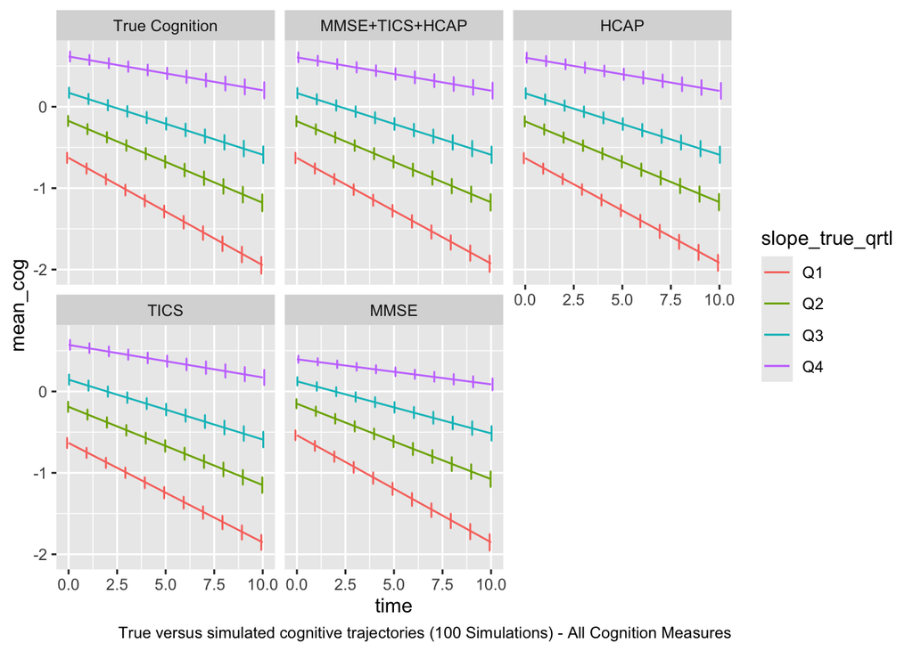

```r
ggplot(data = r4a, aes(x = time, y = mean_cog, color = slope_true_qrtl)) +
    geom_line() +
    geom_errorbar(aes(ymin=lower, ymax=upper), width=.3, position=pd) +
    facet_wrap(vars(cognitive_measure)) +
    labs(caption = "True versus simulated cognitive trajectories (100 Simulations) - All Cognition Measures")
```

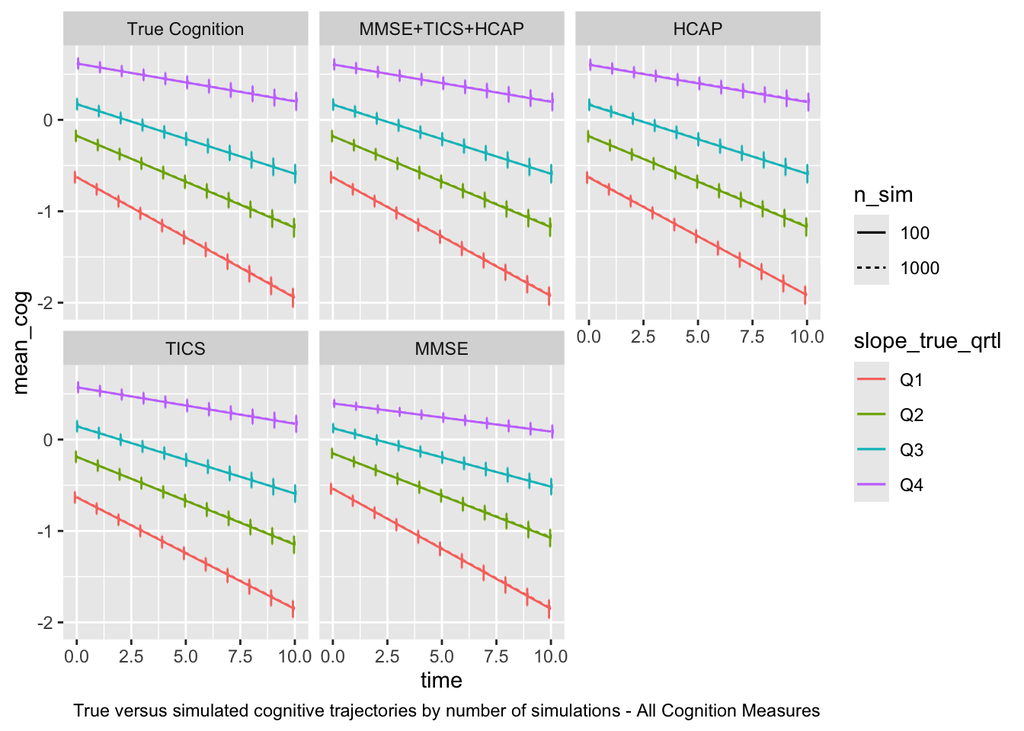

```r
r4 <- r4 %>% mutate(n_sim = 1000)
r4a <- r4a %>% mutate(n_sim = 100)


r10 <- r4 %>% bind_rows(r4a) %>% mutate(
  n_sim = factor(n_sim, levels = c(100,1000))
)

ggplot(data = r10, aes(x = time, y = mean_cog, color = slope_true_qrtl,
        linetype = n_sim)) +
    geom_line() +
    geom_errorbar(aes(ymin=lower, ymax=upper), width=.3, position=pd) +
    facet_wrap(vars(cognitive_measure)) +
    labs(caption = "True versus simulated cognitive trajectories by number of simulations - All Cognition Measures")
```

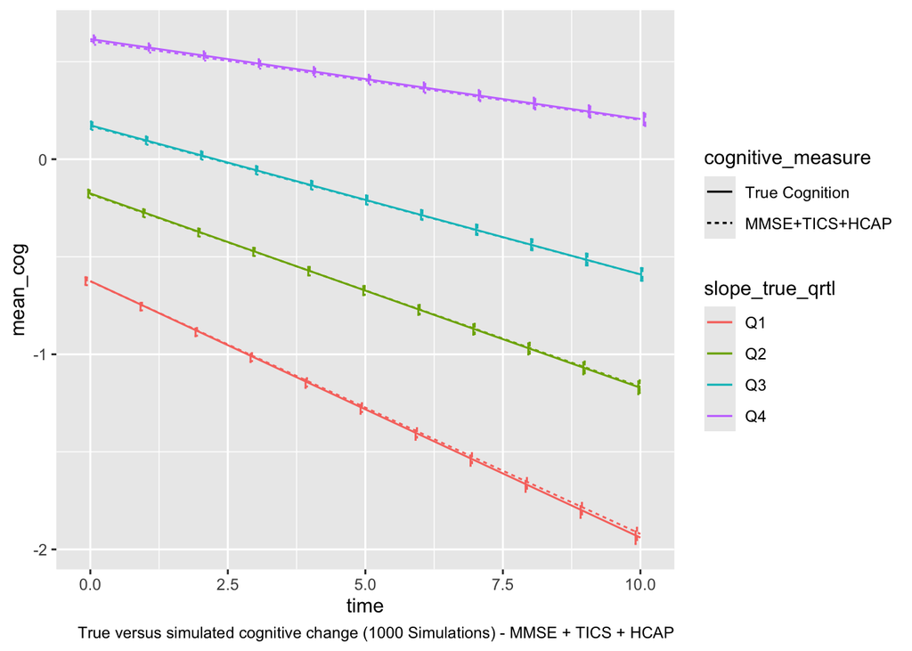

```r
r5 <- r4 %>% filter(cognitive_measure %in% c("MMSE+TICS+HCAP","True Cognition"))

ggplot(data = r5, aes(x = time, y = mean_cog, color = slope_true_qrtl,
    linetype = cognitive_measure)) +
    geom_line() +
    geom_errorbar(aes(ymin=lower, ymax=upper), width=.3, position=pd) +
    labs(caption = "True versus simulated cognitive change (1000 Simulations) - MMSE + TICS + HCAP")
```

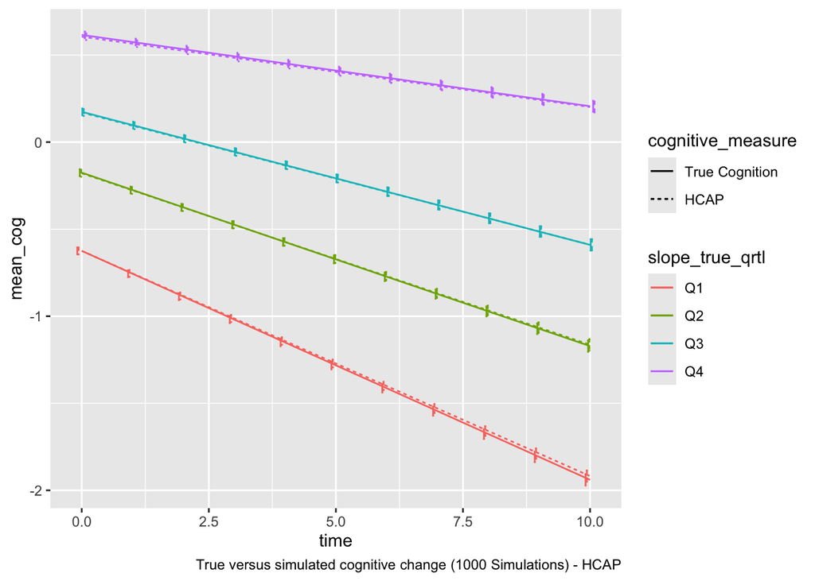

```r
r6 <- r4 %>% filter(cognitive_measure %in% c("HCAP","True Cognition"))

ggplot(data = r6, aes(x = time, y = mean_cog, color = slope_true_qrtl,
    linetype = cognitive_measure)) +
    geom_line() +
    geom_errorbar(aes(ymin=lower, ymax=upper), width=.3, position=pd) +
    labs(caption = "True versus simulated cognitive change (1000 Simulations) - HCAP")
```

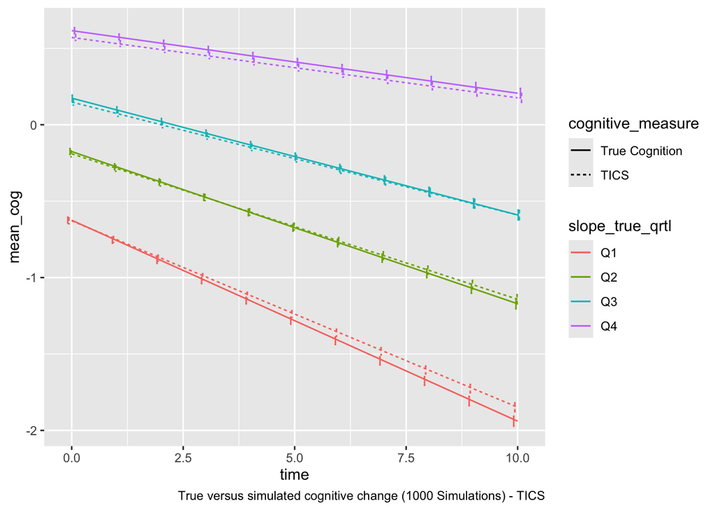

```r
r7 <- r4 %>% filter(cognitive_measure %in% c("TICS","True Cognition"))

ggplot(data = r7, aes(x = time, y = mean_cog, color = slope_true_qrtl,
    linetype = cognitive_measure)) +
    geom_line() +
    geom_errorbar(aes(ymin=lower, ymax=upper), width=.3, position=pd) +
    labs(caption = "True versus simulated cognitive change (1000 Simulations) - TICS")
```

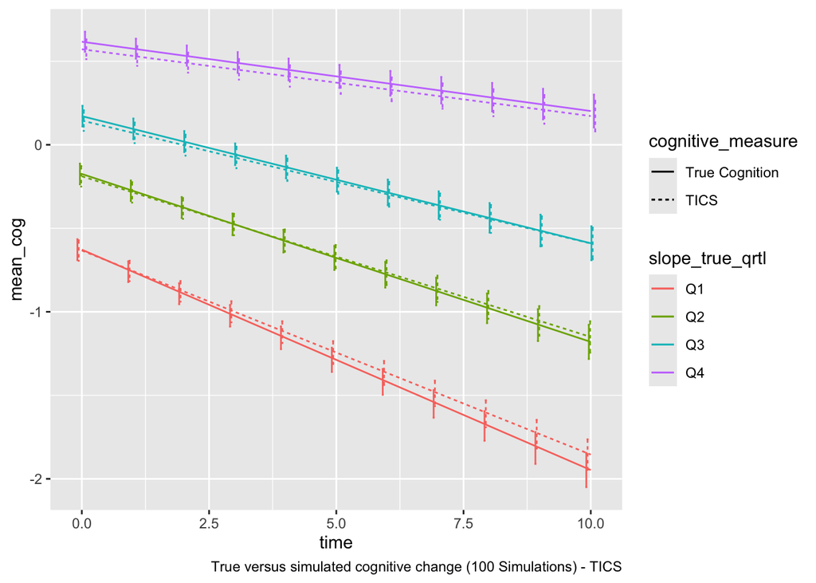

```r
r7a <- r4a %>% filter(cognitive_measure %in% c("TICS","True Cognition"))

ggplot(data = r7a, aes(x = time, y = mean_cog, color = slope_true_qrtl,
    linetype = cognitive_measure)) +
    geom_line() +
    geom_errorbar(aes(ymin=lower, ymax=upper), width=.3, position=pd) +
    labs(caption = "True versus simulated cognitive change (100 Simulations) - TICS")
```

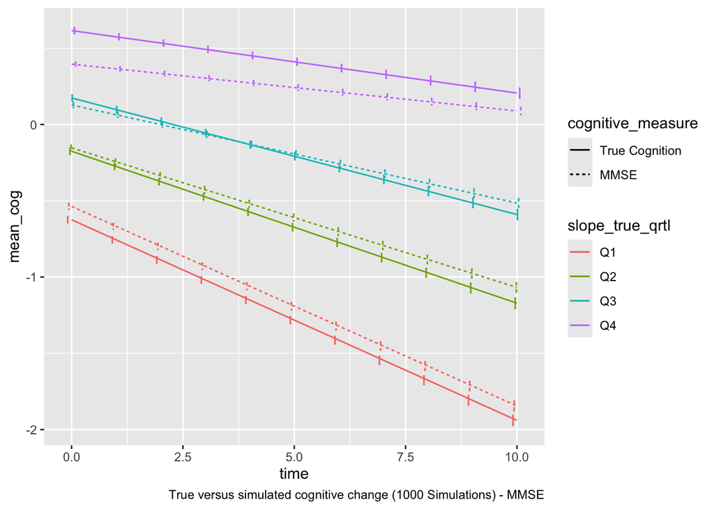

```r
r8 <- r4 %>% filter(cognitive_measure %in% c("MMSE","True Cognition"))

ggplot(data = r8, aes(x = time, y = mean_cog, color = slope_true_qrtl,
    linetype = cognitive_measure)) +
    geom_line() +
    geom_errorbar(aes(ymin=lower, ymax=upper), width=.3, position=pd) +
    labs(caption = "True versus simulated cognitive change (1000 Simulations) - MMSE")
```

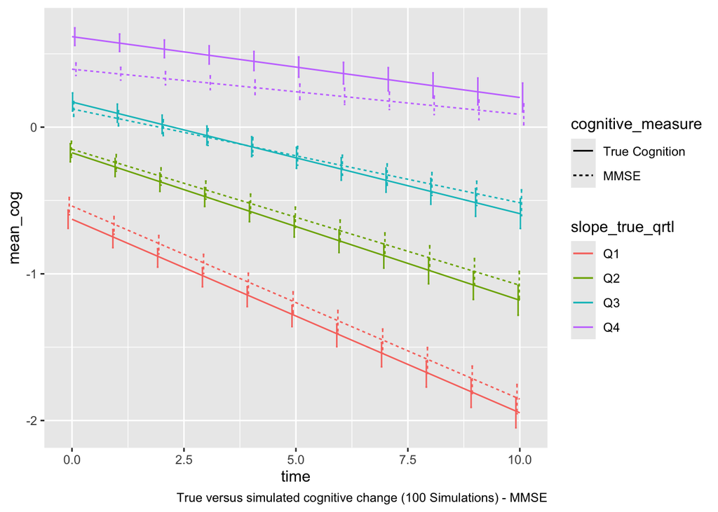

```r
r8a <- r4a %>% filter(cognitive_measure %in% c("MMSE","True Cognition"))

ggplot(data = r8a, aes(x = time, y = mean_cog, color = slope_true_qrtl,
    linetype = cognitive_measure)) +
    geom_line() +
    geom_errorbar(aes(ymin=lower, ymax=upper), width=.3, position=pd) +
    labs(caption = "True versus simulated cognitive change (100 Simulations) - MMSE")
```

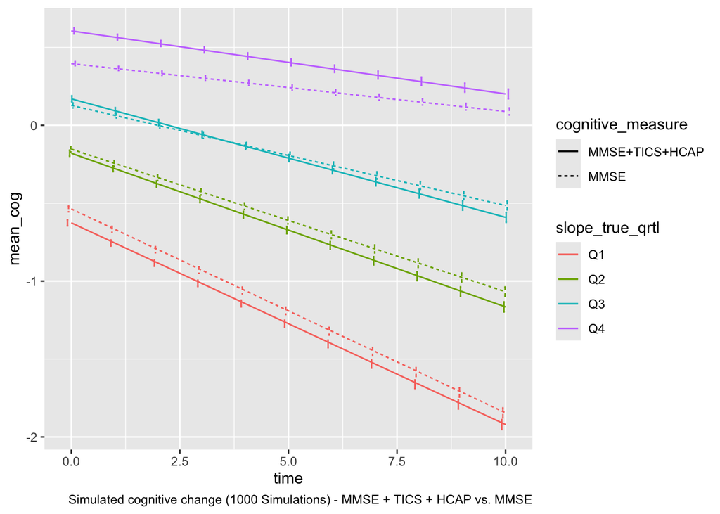

```r
r9 <- r4 %>% filter(cognitive_measure %in% c("MMSE+TICS+HCAP","MMSE"))

ggplot(data = r9, aes(x = time, y = mean_cog, color = slope_true_qrtl,
        linetype = cognitive_measure)) +
    geom_line() +
    geom_errorbar(aes(ymin=lower, ymax=upper), width=.3, position=pd) +
    labs(caption = "Simulated cognitive change (1000 Simulations) - MMSE + TICS + HCAP vs. MMSE")
```

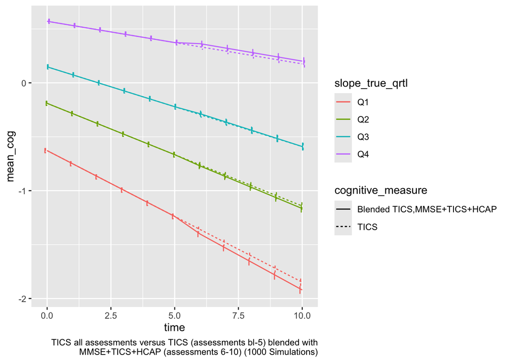

```r
ggplot(data = r4ta, aes(x = time, y = mean_cog, color = slope_true_qrtl,
      linetype = cognitive_measure)) +
    geom_line() +
    geom_errorbar(aes(ymin=lower, ymax=upper), width=.3, position=pd) +
    labs(caption = str_wrap("TICS all assessments versus TICS (assessments bl-5) blended with MMSE+TICS+HCAP (assessments 6-10) (1000 Simulations)",width = 70))
```

```r
rm(r4,r4a,r5,r6,r7,r7a,r8,r8a,r9,r10)
```

### Simple versus Blended Cognitive Trajectories - TICS variants

- Simple trajectories are derived from mixed effects model predicted outcome values for a specific outcome.
- Blended trajectories are derived from mixed effects model predicted outcome values for two outcomes, with the first outcome used for an initial number of assessments (0-5) and the second outcome for subsequent assessments (6-10).

Blended Results. Blending occurs after separate mixed effects models for each outcome are estimated. Plot 1 shows model predicted trajectories for each TICS variant measure. Plot 2 show model predicted trajectories for simple TICS3 and blended TICS3-TICS16.

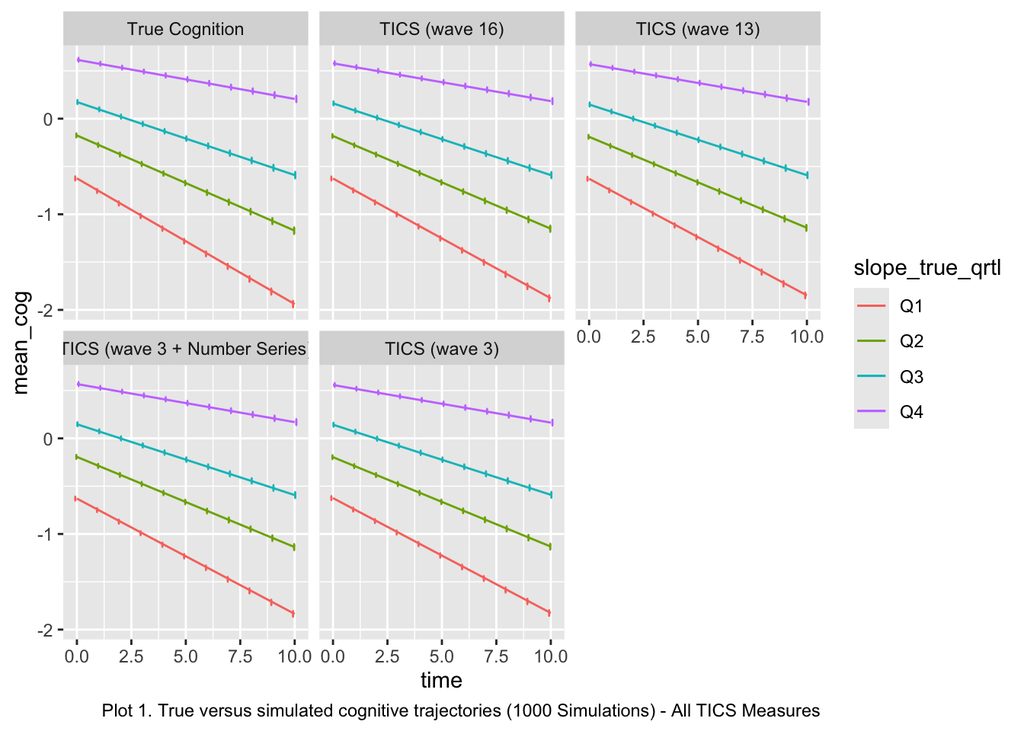

```r
out_dir <- "~/Psychometrics Conference/2024/Simulation WG/PsyMCA-2024-Simulation/Analysis/Simulation Results/tics/"
dat_cols <- c("id","time","agebl_75","slope_true_qrtl","int_true_qrtl")
res_cols <- c("cog_true_pred_tics3","cog_sim_pred_tics3","cog_sim_pred_tics10",
              "cog_sim_pred_tics13","cog_sim_pred_tics16")


r1 <- readRDS(paste0(out_dir,"model_predicted_trajectory_simulations.rds"))

r1$cog_true_pred_mn <- apply(r1[,names(r1)[grepl("cog_true", names(r1))]], 1,
    function(x) mean(x, na.rm = TRUE))
r1$cog_true_pred_se <- apply(r1[,names(r1)[grepl("cog_true", names(r1))]], 1,
    function(x) sd(x, na.rm = TRUE))
# summary(r1$cog_true_mn)
r1$cog_sim_pred_tics3_mn <- apply(r1[,names(r1)[grepl("sim_pred_tics3", names(r1))]], 1,
    function(x) mean(x, na.rm = TRUE))
r1$cog_sim_pred_tics3_se <- apply(r1[,names(r1)[grepl("sim_pred_tics3", names(r1))]], 1,
    function(x) sd(x, na.rm = TRUE))

r1$cog_sim_pred_tics10_mn <- apply(r1[,names(r1)[grepl("sim_pred_tics10", names(r1))]], 1,
    function(x) mean(x, na.rm = TRUE))
r1$cog_sim_pred_tics10_se <- apply(r1[,names(r1)[grepl("sim_pred_tics10", names(r1))]], 1,
    function(x) sd(x, na.rm = TRUE))

r1$cog_sim_pred_tics13_mn <- apply(r1[,names(r1)[grepl("sim_pred_tics13", names(r1))]], 1,
    function(x) mean(x, na.rm = TRUE))
r1$cog_sim_pred_tics13_se <- apply(r1[,names(r1)[grepl("sim_pred_tics13", names(r1))]], 1,
    function(x) sd(x, na.rm = TRUE))

r1$cog_sim_pred_tics16_mn <- apply(r1[,names(r1)[grepl("sim_pred_tics16", names(r1))]], 1,
    function(x) mean(x, na.rm = TRUE))
r1$cog_sim_pred_tics16_se <- apply(r1[,names(r1)[grepl("sim_pred_tics16", names(r1))]], 1,
    function(x) sd(x, na.rm = TRUE))

r2 <- r1 %>% dplyr::select(any_of(dat_cols),contains("_mn"),contains("_se")) %>%
    mutate(age = agebl_75 + 75)
# summary(r2$age)

r3a <- r2 %>% dplyr::select(-c(cog_true_pred_se:cog_sim_pred_tics16_se)) %>%
    pivot_longer(cols = cog_true_pred_mn:cog_sim_pred_tics16_mn,
        names_to = "label", values_to = "cog") %>% mutate(
          label = sub("_mn$","",label)
        )
r3b <- r2 %>% dplyr::select(-c(cog_true_pred_mn:cog_sim_pred_tics16_mn)) %>%
    pivot_longer(cols = cog_true_pred_se:cog_sim_pred_tics16_se,
        names_to = "label", values_to = "cog_se") %>% mutate(
          label = sub("_se$","",label)
        )

r3 <- r3a %>% left_join((r3b %>%
    dplyr::select(id,time,label,cog_se)),by=c("id","time","label")) %>%
    mutate(
        cognitive_measure = factor(case_when(
            label == "cog_true_pred" ~ "True Cognition",
            label == "cog_sim_pred_tics3" ~ "TICS (wave 3)",
            label == "cog_sim_pred_tics10" ~ "TICS (wave 3 + Number Series)",
            label == "cog_sim_pred_tics13" ~ "TICS (wave 13)",
            label == "cog_sim_pred_tics16" ~ "TICS (wave 16)"
        ), levels = c("True Cognition","TICS (wave 16)","TICS (wave 13)",
            "TICS (wave 3 + Number Series)","TICS (wave 3)"))
    )

r4 <- r3 %>% group_by(time,slope_true_qrtl,cognitive_measure) %>% summarise(
    mean_cog = mean(cog),
    se_cog = mean(cog_se) / sqrt(1000)
) %>% mutate(
    lower = mean_cog - (1.96 * se_cog),
    upper = mean_cog + (1.96 * se_cog),
)

r2ta <- r2 %>% dplyr::select(id,time,agebl_75,slope_true_qrtl,
    cog_sim_pred_tics3_mn,cog_sim_pred_tics16_mn,cog_sim_pred_tics3_se,cog_sim_pred_tics16_se) %>%
      mutate(
        cog_blend_mn = case_when(
          time <= 5 ~ cog_sim_pred_tics3_mn,
          time > 5 ~ cog_sim_pred_tics16_mn
        ),
        cog_blend_se = case_when(
          time <= 5 ~ cog_sim_pred_tics3_se,
          time > 5 ~ cog_sim_pred_tics16_se
        )
      ) %>% relocate(cog_blend_mn, .after = cog_sim_pred_tics16_mn)

r3taa <- r2ta %>% dplyr::select(-c(cog_sim_pred_tics3_se:cog_blend_se,cog_sim_pred_tics16_mn)) %>%
    pivot_longer(cols = c(cog_sim_pred_tics3_mn,cog_blend_mn),
        names_to = "label", values_to = "cog") %>% mutate(
          label = sub("_mn$","",label)
        )
r3tab <- r2ta %>% dplyr::select(-c(cog_sim_pred_tics3_mn:cog_blend_mn,cog_sim_pred_tics16_se)) %>%
    pivot_longer(cols = c(cog_sim_pred_tics3_se,cog_blend_se),
        names_to = "label", values_to = "cog_se") %>% mutate(
          label = sub("_se$","",label)
        )

r3ta <- r3taa %>% left_join((r3tab %>%
    dplyr::select(id,time,label,cog_se)),by=c("id","time","label")) %>%
    mutate(
        cognitive_measure = factor(case_when(
            label == "cog_sim_pred_tics3" ~ "TICS (wave 3)",
            label == "cog_blend" ~ "Blended TICS (wave 3),TICS (wave 16)"
        ), levels = c("Blended TICS (wave 3),TICS (wave 16)","TICS (wave 3)"))
    )

r4ta <- r3ta %>% group_by(time,slope_true_qrtl,cognitive_measure) %>% summarise(
    mean_cog = mean(cog),
    se_cog = mean(cog_se) / sqrt(1000)
) %>% mutate(
    lower = mean_cog - (1.96 * se_cog),
    upper = mean_cog + (1.96 * se_cog),
)

rm(r2,r3,r3a,r3b,r2ta,r3ta,r3taa,r3tab)


ggplot(data = r4, aes(x = time, y = mean_cog, color = slope_true_qrtl)) +
    geom_line() +
    geom_errorbar(aes(ymin=lower, ymax=upper), width=.3, position=pd) +
    facet_wrap(vars(cognitive_measure)) +
    labs(caption = "Plot 1. True versus simulated cognitive trajectories (1000 Simulations) - All TICS Measures")
```

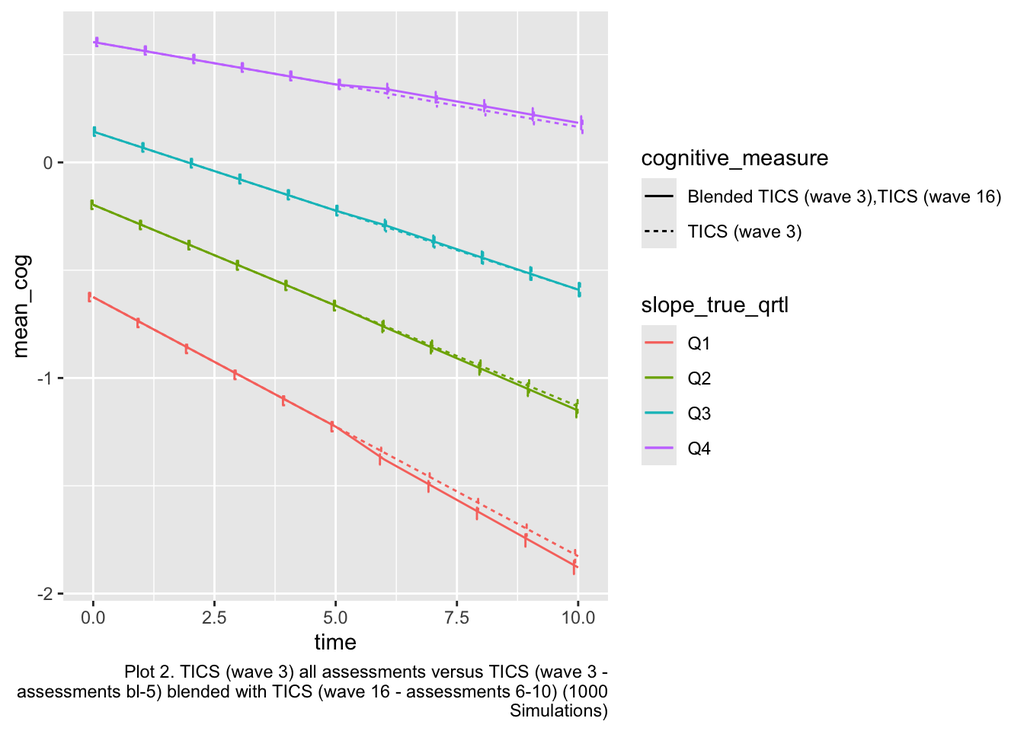

```r
ggplot(data = r4ta, aes(x = time, y = mean_cog, color = slope_true_qrtl,
      linetype = cognitive_measure)) +
    geom_line() +
    geom_errorbar(aes(ymin=lower, ymax=upper), width=.3, position=pd) +
    labs(caption = str_wrap("Plot 2. TICS (wave 3) all assessments versus TICS (wave 3 - assessments bl-5) blended with TICS (wave 16 - assessments 6-10) (1000 Simulations)",width = 70))
```

Blended Data - Cognitive scores for different outcomes are blended and inputted into mixed effects models.

Blended Data. Blending of two cognitive measures into one outcome occurs before mixed effects model is estimated. Plot 1a shows model predicted trajectories for simple TICS measures and selected blended measures. Plot 2a shows model predicted trajectories for simple TICS3 and blended TICS3-TICS16.

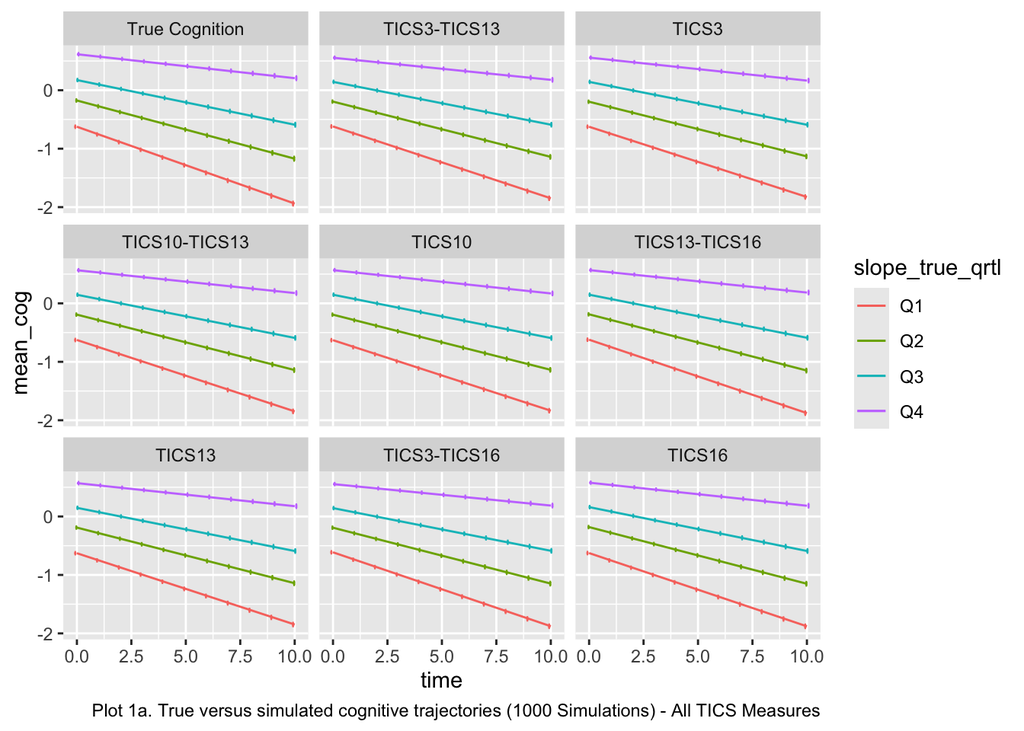

```r
# prepare longitudinal data file

out_dir <- "~/Psychometrics Conference/2024/Simulation WG/PsyMCA-2024-Simulation/Analysis/Simulation Results/tics_blends/"
dat_cols <- c("id","time","agebl_75","slope_true_qrtl","int_true_qrtl")
res_cols <- c("cog_true_pred_tics3-tics13","cog_sim_pred_tics3-tics13",
    "cog_sim_pred_tics3-tics3","cog_sim_pred_tics10-tics13",
    "cog_sim_pred_tics10-tics10","cog_sim_pred_tics13-tics16",
    "cog_sim_pred_tics13-tics13")


r1 <- readRDS(paste0(out_dir,"model_predicted_trajectory_simulations.rds"))

r1$cog_true_pred_mn <- apply(r1[,names(r1)[grepl("cog_true", names(r1))]], 1,
    function(x) mean(x, na.rm = TRUE))
r1$cog_true_pred_se <- apply(r1[,names(r1)[grepl("cog_true", names(r1))]], 1,
    function(x) sd(x, na.rm = TRUE))
# summary(r1$cog_true_mn)
r1$`cog_sim_pred_tics3-tics13_mn` <- apply(r1[,names(r1)[grepl("sim_pred_tics3-tics13", names(r1))]], 1,
    function(x) mean(x, na.rm = TRUE))
r1$`cog_sim_pred_tics3-tics13_se` <- apply(r1[,names(r1)[grepl("sim_pred_tics3-tics13", names(r1))]], 1,
    function(x) sd(x, na.rm = TRUE))

r1$`cog_sim_pred_tics3-tics3_mn` <- apply(r1[,names(r1)[grepl("sim_pred_tics3-tics3", names(r1))]], 1,
    function(x) mean(x, na.rm = TRUE))
r1$`cog_sim_pred_tics3-tics3_se` <- apply(r1[,names(r1)[grepl("sim_pred_tics3-tics3", names(r1))]], 1,
    function(x) sd(x, na.rm = TRUE))

r1$`cog_sim_pred_tics10-tics13_mn` <- apply(r1[,names(r1)[grepl("sim_pred_tics10-tics13", names(r1))]], 1,
    function(x) mean(x, na.rm = TRUE))
r1$`cog_sim_pred_tics10-tics13_se` <- apply(r1[,names(r1)[grepl("sim_pred_tics10-tics13", names(r1))]], 1,
    function(x) sd(x, na.rm = TRUE))

r1$`cog_sim_pred_tics10-tics10_mn` <- apply(r1[,names(r1)[grepl("sim_pred_tics10-tics10", names(r1))]], 1,
    function(x) mean(x, na.rm = TRUE))
r1$`cog_sim_pred_tics10-tics10_se` <- apply(r1[,names(r1)[grepl("sim_pred_tics10-tics10", names(r1))]], 1,
    function(x) sd(x, na.rm = TRUE))

r1$`cog_sim_pred_tics13-tics16_mn` <- apply(r1[,names(r1)[grepl("sim_pred_tics13-tics16", names(r1))]], 1,
    function(x) mean(x, na.rm = TRUE))
r1$`cog_sim_pred_tics13-tics16_se` <- apply(r1[,names(r1)[grepl("sim_pred_tics13-tics16", names(r1))]], 1,
    function(x) sd(x, na.rm = TRUE))

r1$`cog_sim_pred_tics13-tics13_mn` <- apply(r1[,names(r1)[grepl("sim_pred_tics13-tics13", names(r1))]], 1,
    function(x) mean(x, na.rm = TRUE))
r1$`cog_sim_pred_tics13-tics13_se` <- apply(r1[,names(r1)[grepl("sim_pred_tics13-tics13", names(r1))]], 1,
    function(x) sd(x, na.rm = TRUE))

r1$`cog_sim_pred_tics3-tics16_mn` <- apply(r1[,names(r1)[grepl("sim_pred_tics3-tics16", names(r1))]], 1,
    function(x) mean(x, na.rm = TRUE))
r1$`cog_sim_pred_tics3-tics16_se` <- apply(r1[,names(r1)[grepl("sim_pred_tics3-tics16", names(r1))]], 1,
    function(x) sd(x, na.rm = TRUE))

r1$`cog_sim_pred_tics16-tics16_mn` <- apply(r1[,names(r1)[grepl("sim_pred_tics16-tics16", names(r1))]], 1,
    function(x) mean(x, na.rm = TRUE))
r1$`cog_sim_pred_tics16-tics16_se` <- apply(r1[,names(r1)[grepl("sim_pred_tics16-tics16", names(r1))]], 1,
    function(x) sd(x, na.rm = TRUE))

r2 <- r1 %>% dplyr::select(any_of(dat_cols),contains("_mn"),contains("_se")) %>%
    mutate(age = agebl_75 + 75)
# summary(r2$age)

r3a <- r2 %>% dplyr::select(-c(cog_true_pred_se:`cog_sim_pred_tics16-tics16_se`)) %>%
    pivot_longer(cols = cog_true_pred_mn:`cog_sim_pred_tics16-tics16_mn`,
        names_to = "label", values_to = "cog") %>% mutate(
          label = sub("_mn$","",label)
        )
r3b <- r2 %>% dplyr::select(-c(cog_true_pred_mn:`cog_sim_pred_tics16-tics16_mn`)) %>%
    pivot_longer(cols = cog_true_pred_se:`cog_sim_pred_tics16-tics16_se`,
        names_to = "label", values_to = "cog_se") %>% mutate(
          label = sub("_se$","",label)
        )

r3 <- r3a %>% left_join((r3b %>%
    dplyr::select(id,time,label,cog_se)),by=c("id","time","label")) %>%
    mutate(
        cognitive_measure = factor(case_when(
            label == "cog_true_pred" ~ "True Cognition",
            label == "cog_sim_pred_tics3-tics13" ~ "TICS3-TICS13",
            label == "cog_sim_pred_tics3-tics3" ~ "TICS3",
            label == "cog_sim_pred_tics10-tics13" ~ "TICS10-TICS13",
            label == "cog_sim_pred_tics10-tics10" ~ "TICS10",
            label == "cog_sim_pred_tics13-tics16" ~ "TICS13-TICS16",
            label == "cog_sim_pred_tics13-tics13" ~ "TICS13",
            label == "cog_sim_pred_tics3-tics16" ~ "TICS3-TICS16",
            label == "cog_sim_pred_tics16-tics16" ~ "TICS16",
        ), levels = c("True Cognition","TICS3-TICS13","TICS3","TICS10-TICS13",
                "TICS10","TICS13-TICS16","TICS13","TICS3-TICS16","TICS16"))
    )

r4 <- r3 %>% group_by(time,slope_true_qrtl,cognitive_measure) %>% summarise(
    mean_cog = mean(cog),
    se_cog = mean(cog_se) / sqrt(1000)
) %>% mutate(
    lower = mean_cog - (1.96 * se_cog),
    upper = mean_cog + (1.96 * se_cog),
)

r2ta <- r2 %>% dplyr::select(id,time,agebl_75,slope_true_qrtl,
    `cog_sim_pred_tics3-tics3_mn`,`cog_sim_pred_tics3-tics16_mn`,
    `cog_sim_pred_tics3-tics3_se`,`cog_sim_pred_tics3-tics16_se`) # %>%
      # mutate(
      #   cog_blend_mn = case_when(
      #     time <= 5 ~ cog_sim_pred_tics3_mn,
      #     time > 5 ~ cog_sim_pred_tics16_mn
      #   ),
      #   cog_blend_se = case_when(
      #     time <= 5 ~ cog_sim_pred_tics3_se,
      #     time > 5 ~ cog_sim_pred_tics16_se
      #   )
      # ) %>% relocate(cog_blend_mn, .after = cog_sim_pred_tics16_mn)

r3taa <- r2ta %>% dplyr::select(-c(`cog_sim_pred_tics3-tics3_se`,`cog_sim_pred_tics3-tics16_se`)) %>%
    pivot_longer(cols = c(`cog_sim_pred_tics3-tics3_mn`,`cog_sim_pred_tics3-tics16_mn`),
        names_to = "label", values_to = "cog") %>% mutate(
          label = sub("_mn$","",label)
        )
r3tab <- r2ta %>% dplyr::select(-c(`cog_sim_pred_tics3-tics3_mn`,`cog_sim_pred_tics3-tics16_mn`)) %>%
    pivot_longer(cols = c(`cog_sim_pred_tics3-tics3_se`,`cog_sim_pred_tics3-tics16_se`),
        names_to = "label", values_to = "cog_se") %>% mutate(
          label = sub("_se$","",label)
        )

r3ta <- r3taa %>% left_join((r3tab %>%
    dplyr::select(id,time,label,cog_se)),by=c("id","time","label")) %>%
    mutate(
        cognitive_measure = factor(case_when(
            label == "cog_sim_pred_tics3-tics3" ~ "TICS (wave 3)",
            label == "cog_sim_pred_tics3-tics16" ~ "Blended TICS (wave 3),TICS (wave 16)"
        ), levels = c("Blended TICS (wave 3),TICS (wave 16)","TICS (wave 3)"))
    )

r4ta <- r3ta %>% group_by(time,slope_true_qrtl,cognitive_measure) %>% summarise(
    mean_cog = mean(cog),
    se_cog = mean(cog_se) / sqrt(1000)
) %>% mutate(
    lower = mean_cog - (1.96 * se_cog),
    upper = mean_cog + (1.96 * se_cog),
)

rm(r2,r3,r3a,r3b,r2ta,r3ta,r3taa,r3tab)

ggplot(data = r4, aes(x = time, y = mean_cog, color = slope_true_qrtl)) +
    geom_line() +
    geom_errorbar(aes(ymin=lower, ymax=upper), width=.3, position=pd) +
    facet_wrap(vars(cognitive_measure)) +
    labs(caption = "Plot 1a. True versus simulated cognitive trajectories (1000 Simulations) - All TICS Measures")
```

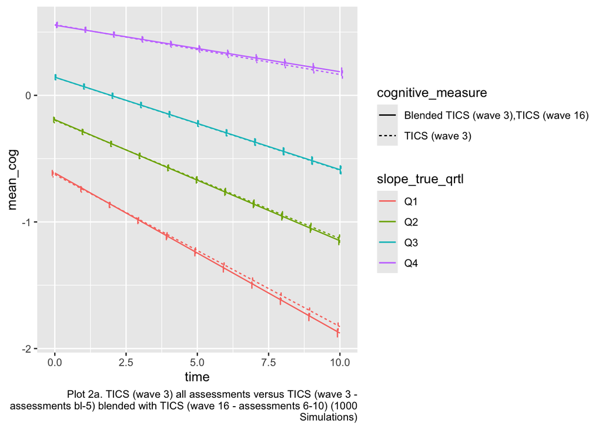

```r
ggplot(data = r4ta, aes(x = time, y = mean_cog, color = slope_true_qrtl,
      linetype = cognitive_measure)) +
    geom_line() +
    geom_errorbar(aes(ymin=lower, ymax=upper), width=.3, position=pd) +
    labs(caption = str_wrap("Plot 2a. TICS (wave 3) all assessments versus TICS (wave 3 - assessments bl-5) blended with TICS (wave 16 - assessments 6-10) (1000 Simulations)",width = 70))
```